# La soute à charbon : Voyage au pays des sherpas du code

jul & tagada johns pour les illustrations

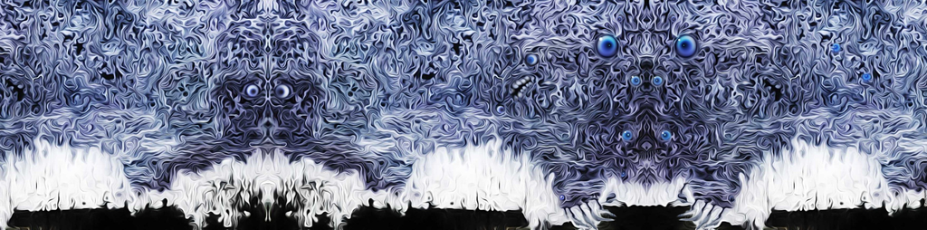

Illustration de tagada Johns

# En mémoire du doude

Il y a longtemps maintenant, j'ai tué un sherpa du code avec lequel on appelait notre taf ; la soute à charbon.

Le matin quand on rentrait, les chefs de projets sentaient le rance. Leur bureau emplis de l'odeur âcre de la sueur, leurs vitres design, parées de couvertures miteuses qui n'auraient pas dépareillées dans un squat de charclos.

Certains étaient là depuis plus de 48h sans interruptions, sans douches.

Mon pote s'appelait Édouard le doude.

Avec lui, et la gang du boulot on faisait la tournée des grands ducs le vendredi soir après des semaines de 50-60h, entre 7 pintes et plus.

Le vendredi c'était aussi le jour où les ressources humaines mensuellement viraient une dizaine d'employé pour assurer une méritocratie darwiniste.

Les virés se bourraient la gueule, les DA prenaient de la coke et ce beau monde vomissaient dans les locaux classieux classés au patrimoine historique.

Quelques mois plus tard, le Doude (Édouard) qui avait décidé d'arrêter les conneries est parti se sevrer en Creuse.

Un 31 décembre il m'a appelé de nul part à 23h00 pour que je l'héberge.

J'étais en cuvage de burnout -la bonne excuse- pinté, seul dans l'apparte vide de ma grand mère qui venait de décéder.

Le lendemain matin à 9:00, la police m'appelait.

Après que je lui ai refusé de lui tendre la main pour avoir un toit, il a retrouvé le chemin du squat où ça dealait de l'héro, et il s'est fait une overdose.

Et il est mort ...

J'en ai marre du bullshit sur l'informatique et le coté privilégié du taf.

Pour un millionnaire, il y a des dizaines de codeurs comme le doude qui sont littéralement pressés comme des citrons, il y a une vraie soute à charbon dont les journaux, les **livres** ne causent pas.

Donc, moi, il me prend l'envie de causer d'Édouard et de tout les sherpas du code, j'ai même travaillé chez abusoft (le petit nom d'ubisoft) : j'en ai fait des marches de la mort que je peux conter.

# Ne fermez pas tout de suite !

## Qui était le doude ?

Bon, le début est abrupt, je devrais plus vous parler du sourire d'Édouard et comment il a jeté un rayon de soleil dans ma vie, qui ironiquement, m'aide encore pendant les périodes sombres.

Mec, sans toi, j'aurais pas acheté ma première barrette de shit à 35 ans quelques mois après notre rencontre.

Comme une deuxième adolescence, mais, positive cette fois.

Musique, discussion, ouverture, du code certes parfois en duo complètement gelés. C'était cool de retrouver après la date sociale d'exemption probable de faire des nouveaux amis d'en trouver un pareil.

En plus, pareil à des ados, on partageait notre secret : nous étions des *huguenots*. Cette espèce mystérieuse de français qui lors de la révocation de l'Édit de Nantes par Louis XIV furent exilés ou occis pendant la guerre de Religion. On estime leur nombre à 12% de la population française de l'époque.

Vous vous en doutez, si on descend de gens, c'est logiquement plus du coté des exilés que des morts qu'il faut regarder.

Lui et moi, on faisait parti des descendants des protestants de l'Est qui avaient migré au plus proche : l'Allemagne.

Notons qu'à l'époque, toute l'Europe a eu accueilli ces réfugiés qui ne parlaient pas leurs langues et causaient de substantielles frictions sur leurs stocks de nourritures. Notons aussi, que ces réfugiés ont contribué au boom économique de TOUTES les nations qui les ont accueilli après coup et ont fragilisé l'hégémonie de la France (c'est un peu con de virer tout ses travailleurs qualifiés quand on a besoin d'armes).

Je dis pas qu'accueillir les réfugiés a évité à l'Europe de subir le joug français dans les siècles qui ont suivi, mais je suggère fortement que le premier dragon de Louis XIV qui a déserté pour la Prussie a littéralement formé l'armée qui va tanner les fesses de la France en 1870 (guerre où mes ancêtres vont se distinguer du coté des Français car ils reviennent avec l'ouverture que Napoléon fait aux protestants).

L'huguenot est français en france, suédois en suède, danois au danemark et émigré quand cela ne lui plaît plus. Et le descendant de huguenot est naturellement enclin au trouble de l'identité nationale multiple. Et, de même qu'à l'époque en 1900 la société questionnait l'amitié franco allemande plutôt que la guerre que prônait certains ré immigrés, on questionne la loyauté des descendants des immigrés nord africains.

Je dis pas que l'Histoire se répète, mais je dis qu'elle a un peu le hoquet.

Si tout les citoyens du monde se comportaient en huguenot, à 16 ans nos états nous lâcheraient la bride pour voyager, et à l'issue de notre « rumspringa » (400 coups), on pourrait choisir si on veut rester de la nationalité qui nous a émancipé.

Ce ne serait plus les états qui décideraient de qui sont leurs citoyens à la naissance et sans discussions à la mode des rois tyranniques, ce seraient les adultes qui choisiraient leur citoyenneté selon leurs goûts comme à l'époque des rois dits fainéants.

Ouais, c'est le genre de discussion qui n'intéresse personne que je pouvais avoir avec le doude.

## Qui donc était cet homme ?

On l'appelait le doude, car c'est la prononciation fainéante de dude (le gars, le mec cool) en français. Et c'est une référence courante dans l'univers du funk qui était sa musique favorite avec le guitare psychédélique des années 1970.

Il était un peu hippy d'apparence, cheveux mi-longs avec un grand sourire un peu jauni (tabac/café), une voix naturellement caverneuse et des yeux comme des fentes de bites en permanence à cause d'un manque de sommeil endémique.

C'était un bon vivant qui logeait dans une turne (un peu minable) de Clichy. Qui avait traîné ses guêtres dans les cités parisiennes et pris sa première dose à 13 ans.

On parlait drogue. Il me parlait beaucoup de comment il avait à cœur de décrocher. Il était sous méthadone. Et il me racontait tout ce qui ne donne pas envie de consommer.

Genre comment l'héroïne s'accroche aux trucs de la douleur dans le cerveau mais comme c'est plus fort que le truc que ça mime dans le cerveau (capteur d'endorphine) : ça les niques, et pendant un certain temps tu vas plus avoir de capteur de calmant anti-douleurs naturels qui marchent. Trolololol.

Tu vois le mal de dent sans tes précieuses endorphines ? Et ben, ça fait très mal.

Valà. La drogue, surtout l'héroïne : c'est pas bien. C'est pas moi qui le dit : c'est le doude.

C'est pour ça que je l'admirais. Vous-savez-tu je fais de la boxe. Et j'aime le petit teigneux qu'a morflé sévère mais qui prend sur lui de se relever pour se battre.

Des camés (héroïne, acide, alcool, crack, shit) j'en ai rencontré depuis le collège. Et je dirais que l'alcool a été la première drogue à apparaître.

J'ai grandi dans un coin où quand j'arrivais la première cause de mortalité était encore l'alcoolisme car les patrons du Vexin avait payé leur salarié de l'entre deux guerre pour un tiers en mauvaise gnôle et ils crevaient de cirrhose.

Et ... se moquer des camés à cette époque revenait à rigoler de la paille dans la poutre qui était dans mon œil. L'alcool : c'est une sale came. C'est pas le doude qui le dit : c'est moi.

C'est comme le tabac, un sujet délicat où je navigue entre reprise de contrôle (ouf) et petite dérive. Entre « sous contrôle », et « à quoi bon se faire chier quand le paramètre le plus létale (l'exposition à la pollution de l'air) n'est pas sous mon contrôle ? »

À quoi bon te protéger d'une météorite quand l'air te tue (de manière indolore, incolore, inodore) ? Il faut se faire un peu plaisir dans la vie avant de clamser, non ?

Celui qui diffère de jouir ne s'apercevant pas qu'un poison mortel a été versé à la source de notre vie est en train de gâcher quelque chose.

Vous savez le gars qui bosse toute sa vie pour payer sa pierre tombale (ou autre monument de vanité comme une théorème à son nom ou une médaille sportive).

À chaque âge sa came. Moi en ce moment c'est l'écriture, puis je me reverrais bien profiter de mes dernières années avec un squelette pas trop ramollo pour faire de la boxe. Ce serait dommage de se priver de risquer de se faire crever les tympans ou pocher le nez, pas vrai ?

Et le pire, c'est que je déteste me battre.

## Qui donc était cet homme égaré parmi nous ?

Un musicien.

Pas un *grand* musicien, mais *le* musicien que l'on souhaite tous avoir comme ami.

Brûlé par des années d'apprentissage de musique classique/jazz casse couille j'avais développé une allergie à jouer de la musique. Toucher un instrument.

Et là, il m'a redonné le goût de jouer, de repartir de zéro, j'ai même fait un blocage sur le solfège et utilise les tablatures pour jouer de la basse.

Alors, bon vous voyez où ça nous mène : il aime le funk, j'aime la basse.

Y'avait même un 2é zikos dans la gang qui interagissait bien avec le doude et qu'était dans le même délire musicale de jouer et entraîner à jouer plus que d'être reconnu. Une musique de bord de rue comme on peut en voir à Montréal quand on sait où se promener.

Le prisme. Lui, il est DJ, il est dans l'électro, il aime les grosses basses.

On était fait pour s'entendre. Et retrouver le goût de la musique même tard, ça valait le coup.

C'est pour ça que je dis que j'ai eu une chouette période d'adulescence (adolescence adulte) avec le doude et le prisme.

Et tous, j'ai oublié le principal on était à fond dans le code et passionnés de faire et de technique. On a fait des super projets ensembles dont je suis aussi fiers que des conneries que l'on a faites après les heures de bureaux :D

C'était un pote comme on en rêve.

# La gang

## L'art de se présenter

Quand le duke avec sa chemise de bûcheron rouge et blanche que je ne connaissais pas encore m'a demandé de me présenter je lui ai dit de mémoire

> Je suis un banlieusard croisé avec un bûcheron canadien.

Avec la chanson (qui maintenant me paraît de l'humour de gros con de Cleese) je pensais surtout à la partie *« I'm a lumberjack and I'm Okay, works all night and sleep all day »*.

Ça a pu surprendre. Surtout qu'il est pas courant pour un babtou de se dire banlieusard. Quand on est blanc, il paraît que les stigmates de banlieue nous touchent pas. En ce qui me concerne je sais simplement que j'ai commencé à avoir des réponses à des offres d'emplois autant sur Paris qu'en banlieue en mettant mon adresse chez ma grand mère parisienne. Et j'ai aussi découvert dans les facs parisiennes avec beaucoup de bourges de toute la france (faut payer la location ou avoir du piston pour le CROUS) que mes co-étudiants n'aimaient pas trop les banlieusards. Donc, comme ça faisait partie de ma vie à l'époque, j'étais banlieusard jusqu'au bout des ongles et jusqu'à la provoc.

## Un open space comme on les aime

Évidemment, j'étais en openspace, les bureaux fermés insonorisés étant réservés la plupart du temps aux VIP : les chefs de projets et autres vizir.

Le bureau vitré des Chef de proj avait de gentils mémos genre « martine vide son cache » et autres rappel à vérifier avant de dire « *bug!* ».

Les gens présents étaient honnêtement compétents en HTML, flash, CSS et javascript. C'était à l'époque de la guerre des brouteurs webs quand il fallait faire des bidouilles partout autant en javascript qu'en CSS ou HTML pour s'accommoder de ce bordel sans nom, et malheureusement *jquery* n'en était qu'à ses débuts. Jquery pour ceux qui ne le savent était un sucre syntaxique élégant au dessus de javascript qui prenait en charge les différences entre versions de javascript et du modèle de document (DOM). Je me permet un petit saut dans le futur en disant qu'aujourd'hui jquery est encore présent sur 30% des sites webs alors que son but recherché de faire converger les brouteurs web a été atteint.

Il n'y a littéralement plus besoin de jquery aujourd'hui et tout que ce que jquery a proposé comme innovation a été intégré dans les versions de javascript encore en vie.

C'était aussi à l'époque de la folie PHP et de faire l'hébergement mutualisé sur des VPS.

Je venais plus du « back » (partie serveur) que du « front » (partie blingbling) de la production, mais ça me dérangeait pas avec des collègues savants et bienveillants, *a priori* ça ne pouvait que bien se passer. Non ?

Sachant que j'avais déjà quelques années de mercenariat (auto-entrepreneur) dans les pattes j'étais habitué à être envoyé en mission pompier à droite et à gauche soit pour éteindre des incendies de code en perdition, soit pour staffer en marche des équipes en tension car j'étais pas long à former.

La gang était fait de plusieurs tribus qui s'entendaient bien : les flasheux, qui développaient sur une technologie aujourd'hui disparue appelée « flash », les pisseurs de HTML/CSS qui étaient en mode donner le rendu conforme aux indications données soit sous formes fichiers photoshop (à l'époque les gens prenaient encore le web pour un espèce de papier magique), soit de powperpoint qui disaient tout sauf ce que l'on avait besoin de savoir, et enfin les intégrateurs. Des gens capables de faire un peu de DB, ssh, sysadmin, PHP pour faire bouger le papier magique.

Puis, il y avait toute la ribambelle classique de non-ouvriers de prod en train de cornaquer : les directeurs techniques, les chefs de projets, les directeurs artistiques.

Ne pensez pas que je les sépare par mépris de classe, on était simplement séparés par un mépris de glace, comme celle des vitres de leurs bureaux.

Chaque fonction dans l'entreprise avait sa place, et ne bougeait pas, ça aide pas à construire un sentiment d'équipe me semble-t'il, mais je m'en fous je ne suis ni RH, ni architecte donc mon avis : il vaut rien.

J'ai un peu oublié tout le monde, y'avait le toulousain -ben- qui chialait tout le temps qu'il voulait revenir au pays, le métis irlando-japonais, clem, qui nous faisait découvrir les meilleurs restos pas chers de paname, pik et duke les skaters fous, le doude.

Dans les mercenaires, il y avait prisme, un graphiste indé avec qui le courant passait bien. On en a fait des soirées ensembles après ...

Et cette gang n'était pas que compétente, elle aimait partager, ce qui fait que j'en ai profité pour apprendre des meilleurs le HTML/CSS/javascript.

Si un jour je les revois je leur dirais bien merci car à l'époque mon niveau dans le domaine était un peu léger.

## Le jour où je suis devenu pote avec le doude

C'est un jour de baroud pour fêter un chantier (projet en jargon informatique) qu'on avait terminé et pour lequel tout le plateau était invité qu'on était ensemble.

J'étais à coté du doude que je ne connaissais pas encore et je lui ai dit :

> Pour un projet où l'on a trimé, ils ont invité tout le plateau (dont ceux qui ont rien à voir) 49 personnes pour partager 7 bouteilles. C'est du foutage de gueule.

Et tel Robin de la Soute à Charbon je suis allé près du buffet et j'ai eu glissé une bouteille de champagne dans la manche de mon blouson en cuir, soustrayant ni vu ni connu une bouteille d'un partage injuste des fruits du travail avec ses camarades prolétaires. Nan, je déconne, j'étais juste un gars qui voulait boire plus et eux aussi.

Et donc on est sorti dans le parc devant les locaux avec la gang et on s'est présenté, et il a fait tourner un bédot de fort bonne qualité. Je suis sûr qu'il y avait le pik et le prisme.

Il a kiffé mon audace, j'ai aimé être reconnu pour mon talent :D

Ce qui me fait pensé que je parle déjà de la soute sans avoir commencé à en parler. Ce n'est que partie remise.

# Parler comme un livre, où écrire comme on jacte (à la gare de l'Est) ?

Là d'où j'ai grandi, parler comme un livre, c'est un compliment, de celui qui s'exprime d'une manière qui émerveille.

Quand j'étais déménageur ça voulait dire parler doctement et t'expliques tout de choses qu'il ne sait pas faire : synonyme de branleur ou consultant TI.

Quand ils ont vu que je savais démonter un meuble avec ma clé de poche pour vélo, ils ont arrêté de me dire que je parlais comme un livre. Ça s'appelle surmonter les handicaps liés aux préjudices.

Non que je sois opposés à leur point de vue, je dirais même que je le partage, mais mon coté inadapté social fait que je prend un peu de temps à bien causer comme le péquin avec lequel je turbine. Donc, des fois j'ai du retard à l'allumage sur le comportement social, l'accent et le vocabulaire.

C'est terrible de ne pas fréquenter qu'un milieu social et linguistique. À chaque groupe il faut changer ses mots et intonations et se méfier des faux amis.

Ce qui pour le conio de la rue veut dire l'évidence, veut dire la preuve par calque avec l'anglais chez les managers qui ont trop biberonné d'anglais. Ils ne corrigent plus leurs trous dans leurs infras : ils fixent les issues. L'absurdité en français de fixer les issues pour éviter à un bateau de couler crée donne envie de pouffer en réunion.

L'illusion qu'il existe UN français qui nous dominerait tous, c'est de l'ébousgroufe, de l'entourloupe, du foutage de gueule.

Je ne critique pas, mais je dis *verge*. Je dis qu'on diverge, et je trouve ça cool.

Non, que je serais contre que ça change, et je rêve de règles de simplifications. Je suis même tenter de dire -mais merde- pourquoi on colle un sexe sur tout ?

Est-ce qu'il faut voir derrière LA voiture qui essaie de RENVERSER MON VÉLO une tentative d'accouplement ? Est-ce que ça porte du sens que le vélo soit un trav qui en jouant de la pédale devienne UNE bicyclette ? Est-ce que c'est sensé qu'un motocycle électrique (une moto) débridé soit à 50 de blinde sur les pistes cyclables car un quidam appelle ça un vélo à assistance électrique ?

Je sais pas ce qui se passe avec le français, mais les mots deviennent absurdes souvent aidés par une bureaucratie qui nous vend de l'absurdité.

J'en suis au point où vu qu'on condamne les masses à vivre leurs dernières générations, autant qu'on leur foute la paix.

On devrait vider les caisses de tout les états et faire la fête jusqu'à ce que le réchauffement climatique rende le monde invivable.

Je propose même qu'on laisse un grand terrain en alaska pour que ceux qui ont envie de se taper dessus se tapent dessus une bonne fois pour toute.

On parle pas la même langue car la langue est auto-référentielle, et on ne peux pas échapper à « je », ni à « nous »; donc elle converge et diverge au gré des gens qu'on rencontre et de leurs histoires.

Pour pas introduire de biais il faut parler de soi quand on parle des autres, pour diminuer les malentendus. Le doude, l'avait le parler titi ayant grandi dans les quartiers mixtes avec grands ensembles dans le sud de Paname. C'est peut être à 13 ans m'a-t'il dit, qu'il avait eu sa première l'expérience avec l'héroïne.

> Tu vois, dit-t'il, le plaisir est si intense que tu veux le retrouver à nouveau, manque de pot à chaque fois ton plaisir ressenti est moindre, donc certains sont tentés de monter les doses pour rester à plaisir égal.

> Tu sais moi j'ai arrêté les conneries, d'ailleurs, j'ai un bote en Creuse qui a un podcast qui va m'héberger, et je prends la méthadone.

Je dois admettre qu'il avait parfois les grosses poches sous les yeux quand ils prenait de la codéine.

Ça lui donnait des yeux rigolos.

Donc, voilà, on est prêt à ouvrir la porte de la soute à charbon des sherpas du codes.

# Banlieusard, et alors ?

## Se prendre les clichés dans la figure dès le premier CV

L'acte fondateur de mon embauche en informatique a été de mentir sur mon CV sur mon lieu de résidence, tant pour les études que pour mon premier boulot.

C'est magique comme même pour un babtou comme oimedé (mézigue en verlan), un simple changement d'adresse postale change la donne. D'un seul coup, une adresse de la mère grand dans les beaux quartiers vous fait passer de 0 retours sur 100 CV à 50% de rappels.

Même chose en effaçant stratégiquement le bac +2 dans le public obtenu à 500m de l'ESSEC. À croire que quand il s'agit d'aller faire de la bullshit éco chez les Jésuites la discrimination n'importe plus.

De plus, la *« banlieue »* est un phénomène récent, lié au doublement de la population sur une zone. Résultant dans 2 choses : la hausse des loyers, et la bétonisation/dégradation du niveau de vie. Par contre, avant on se faisait chier car y'avait rien, après on se faisait chier en contemplant les terrains de sport vide 95% du temps où l'on aimerait bien jouer, mais le gardien vous explique que c'est interdit car si on laissait tout le monde en profiter ce serait l'anarchie.

L'immigration ici n'a jamais été un sujet, elle a toujours été traditionnellement divisée entre les ouvriers étrangers moins chers pour remplacer les ouvriers locaux (que ce soit parce qu'avec 1/3 de la paie en nature en mauvaise gnôle le taux d'attrition était élevé, ou que ce soit pour casser les mouvements ouvriers), et les bénéficiaires du droit d'asile pourvu qu'ils aient soutenu une dictature, soient riches et collent pour le FN.

Un ami du XXé à Paname m'expliquait la distinction entre quartiers populaires et ouvriers. Les quartiers populaires sont ... peuplés et cosmopolites de toutes catégories sociales, les quartiers ouvriers sont les anciens ghettos d'avant qu'on vilipende la « racaille ». Ces quartiers comme *« les cordeliers »* dont venait le Charb de Charlie hebdo il y a (à 2km à vol d'oiseau) une tradition orale différente de mon quartier *« Notre Dame » (aka little Portugal)*.

Je suis moi même descendant d'une des nombreuses vagues d'immigration locale dont les plus anciennes avaient leur rue, comme les *ploucs* (terme péjoratifs pour les désigner) de Bretons de la *rue de la Bretonnerie*. Moi, c'est les huguenots (comme le doude), wallons et les creusois. Les immigrés du XIXé, auxquels on expliquait que la messe le dimanche était obligatoire et le syndicalisme une cause de licenciement. Et comme les espinguoins, ripalous ou polak qui ont suivi au XXé siècle on a pas été mieux traité que les précédents, ni que les suivants.

Après, l'émigration africaine a ceci d'aggravant, c'est qu'eux ça se devine à là couleur du faciès comme avant ça se faisait sur les nippes ou sur l'accent.

Pour moi, les cris d'orfraies que je me prends quand on me dénie le droit d'être banlieusard sont les mêmes conneries que ceux qui essaient de cliver les banlieusards entre immigrés récents et anciens. Vous voyez on a une continuité de tradition orale souterraine.

À Pontoise (capitale du Vexin Français), surplombant la gare le fils du pays *-criminel de guerre et casseur du mouvement d'émancipation des esclaves Haïtiens-* se trouve le général Leclerc. Dans les environs, les rues Leclerc sont légions et on a du mal à se souvenir si par hasard ça date pas d'avant la deuxième guerre mondiale.

Ben voyez-vous, en tant que bon banlieusard, comme mon père, d'autres avant et après, [j'ai repeint les couilles de ce fils de sa race d'enfant du pays criminel de guerre et beau frère d'un tyran](https://actu.fr/ile-de-france/pontoise_95500/pontoise-la-statue-contestee-du-general-leclerc-c-est-toute-une-histoire_57570214.html).

Je suis pas spécialement un énervé, c'est juste que je suis plus un actif de l'ombre qu'une grande gueule. Genre plan, quand mes voisins ont leur portail qui grince je m'introduis la nuit dans leur résidence en loucedé pour mettre de l'huile dans les gonds de leur portail et dormir en paix. C'est mon coté bûcheron canadien.

Soyons honnête, avec mon faciès et mon histoire, dans la compétition à la victimisation de banlieue, je joue en mode *« casual »*, je peux parler comme il faut (mais là c'est mon livre, alors j'écris comme ça me plaît), et enfiler un costard pour jouer des claquettes en avant vente. Il reste que la stigmatisation de banlieue touche tout le monde, sinon, j'aurais pas eu besoin de truander mon adresse aussi souvent.

## Start up et discriminations

Well, comment dire, de la part de gens qui sont proches de leurs sous, j'ai jamais compris pourquoi les RHs n'embauchaient pas plus de diversité vu les fossés entre les hommes et les femmes, les « jambons beurres » et les indigènes. Si une chose est sûre c'est que la rationalité annoncée n'est pas au rendez vous quand il s'agit de rogner sur le premier poste de dépense en informatique que sont les salaires.

La discrimination économique est une opportunité, du bon toutou de banlieue qui a envie de faire ses preuves, qui a la niake, ça coûte 20% moins cher qu'un bon fils d'ingé, ingé lui même qui s'est laissé traîné dans des études où il n'a rien à prouver. Pourtant, mystère et boule de gomme, les plateaux sont emplis de BCBG (beau cul belle gueule) à l'accent plat des gens issus de milieux éduqués.

Ils sont mêmes prêts à payer les amendes pour ne pas avoir à embaucher (ce qui donne le droit à des crédits d'impôts) l'une des diversités plus universelle que la banlieue : les handicapés, les GATOREPs.

Et, 5 de mes anciens boss m'ont viré après m'avoir diagnostiqué une maladie mentale : pour certains je suis schyzo, pour d'autres autistes, et enfin pour d'autres ADHD. Pour moi, je ne sais pas ce que je suis, mais je sais que les plus fous sont ceux qui tiennent à être « normaux ». La normalité à mon expérience est aussi rare qu'un champagne sans alcool, et les seuls fous que je connaissais étaient les seuls qui insistaient qu'ils étaient sains d'esprits.

Je ne sais pas si je suis fou, mais je trouve bizarre que les patrons « humanistes » est un tel préjugé contre les gens que l'on pourrait qualifier de neuro divergents (quelque soit la saveur).

Alors, je dis pas que je suis sain, je dis qu'avant le *« burn out »* (brûler jusqu'à l'exhaustion), en anglais il y a le *« burn in »* : le cramage a pleine puissance. Un peu comme une phase maniaque induite avant la phase dépressive.

Peu le réalisent, mais la dépression post-exam ou gros projet à la fac/école c'est déjà un burnout. La fac/l'école vous préparent à ce mode de vie en « gamifiant » avec les notes des phases d'excitation hyper concentrées.

Je plaide coupable a aimer les pics de cortisol (asthmatique j'en gobe parfois à l'insu de mon plein gré au petit déjeuner avant de doubler mon kill death ratio à urban terror grâce au dopage que cela procure) et d'endorphine.

Si l'héroïne colle au cerveau, c'est qu'il y a des récepteurs pour : c'est ceux de l'endorphine ; vous en mangez après une bonne partie de jambe en l'air ou en poussant votre entraînement de sport au delà de l'épuisement. Un shoot d'endorphine on appelle ça *«le second souffle »* en sport. Les junkies du sport sont les biobios tardés de la prise d'héroïne *naturelle*. Là encore, je plaide coupable et cela participe à l'épanouissement de mon couple.

Par contre, l'héro à la différence de l'endorphine reste collée aux neurones, à cause que les enzymes ne les reconnaissent pas (c'est à peu près le même gag avec certaines tazs (argot pour extasy), et surtout on peut sur doser.

## La fête c'est plus fou avec de la DRRROOOOGGGUUUE !

Je ne dis pas qu'il y a une culture de la drogue en informatique, je dis que ne me souviens pas d'une fois où la socialisation en *« after »* (le jargon informaticien pour dire beuverie) s'est faite sans alcool officiellement et/ou officieusement.

Mais, la meilleure drogue reste le *«burn in»* ; le sentiment de surpuissance intellectuelle que l'on peut avoir en phase surexcitée pour résoudre un problème. Le web est rempli de valorisation marche de la mort (death march en anglais, charrette en français) héroïque pour atteindre une livraison (deadline).

Face, tu crames tes neurones à t'exciter et tu compenses avec l'alcool pour dormir, la clope pour avoir des pauses, certains la coco, d'autres la weed. Pile tu cuves ta retombée d'excitation qui va aussi profond que t'es monté haut.

Alors, moi je dis, à ce jeu y'a pas de victimes innocentes, mais peut être des victimes qui sont pas conscientes du prix à payer, et du fait qu'on négocie notre santé mentale dans ce milieu à pas cher. Genre, je me souviens avoir rencontré Jérôme P., aka Mister Docker, au Bénélux de Montréal à ramasser à la petite cuillère. Peu après, il faisait son coming out sur son méga burnout. J'ai eu un peu de mal à avoir de la compassion, il l'avait un peu cherché quand même.

Normal, les supers pouvoirs c'est cool. Mon premier burn-in je l'ai fait pour passer d'élève médiocre à major à Paris VI dans ma promo à cause d'un ennuyeux qui en en cours d'assembleur m'expliquait que j'y connaissais rien en informatique car LUI il avait un ordinateur perso cinq fois plus dispendieux que mon 486DX266 familial (fait avec amour à la main pour satisfaire à moindre coût les besoins de toute la famille).

Le mec, fils d'ingé et donc de bourge, me prenait de haut car je venais de banlieue. Je te l'ai regardé dans les yeux et je lui ai dit : tu vois dans cette matière je vais être le premier pour te faire chier car tu tiens à être le premier, et t'auras pas ce plaisir. Et, je vous le dis, c'était si jouissif que j'en ai coulé une goutte de sperme dans le ben (bénard, futal).

# Pronétaire du monde entier unissez vous !

## No « no pasaran ! »

Je déconne, grâce aux écoles gratuites déjà abusive comme 42 les nouveaux devs font preuves d'une docilité à toute épreuve. Ça change de l'Amérique du Nord où je me suis marié donc que je connais un peu, où les travailleurs sont trois fois plus syndiqués. Icitte, avec le bourrage de crane « made in éducation supérieure » chaque dév on ne sait pas pourquoi a de l'empathie pour son boss. Les sociologues ont un mot pour ça : l'acculturation. Un paradoxe cognitif qui revient à dire que plus une personne est éduquée plus elle est influençable.

La base, c'est une heure travaillée, une heure payée, mais en info, non. Je vous vends le discours classique : « vous ne comptez pas vos heure car vous êtes en forfait cadre annualisé convention SYNTEC ».

[La convention collective SYNTEC](https://www.syntec.fr/convention-collective/) la plus courante dans le métier bien que beaucoup plus favorable que la convention historique de la métallurgie (quand on fondait encore des processeurs en France) aux patrons reste claire : annuellement, c'est 38.5 heures travaillées par semaine avec de la flexibilité jusqu'à 48h max hebdo et 12h max dans une journée.

Autant vous dire que des 70h, 60h, 50h j'en ai enquillé comme les autres. Autant vous dire que quand j'étais sysadmin, j'aimais me foutre la gueule des Chief Happiness Officer nous sensibilisant à l'équilibre « travail / vie perso » en sortant depuis les logs du VPN les horaires des monsieurs la Vertu qui pointaient à 60h et nous faisaient des burnouts explosifs en plein vol.

Ça c'est pour les salariés, pour les auto-entrepreneurs c'est la fête du slip : comme t'es ton patron, tu comptes pas tes heures de travail, plus administratif, plus réseautage alcoolisé pour trouver de nouveaux clients, car une fois qu'un client t'as pressé comme un citron : il va pas te reprendre (l'ingrat).

Ne vous laissez pas compter, il y a bien une logique de comptabilité du temps.

## Le culte des Oscars Baclavas et Xaviers Null, alten, altran et autres viandards

On ne parle pas des montages administratifs qui ont permis à nos « grandes entreprises » d'éviter les syndicats. Il est quand même étonnant me direz vous que la tradition en informatique est de faire des nébuleuses d'entreprises comptant exactement 49 personnes : ça permet d'éviter l'obligation de représentation syndicale commençant à 50 salariés.

Il y a aussi une autre tradition qui est celle des « shorts lists ». L'obligation pour être embauché de passer par des anciens de la boîte qui « portent » les auto-entrepreuneurs. C'est juste de la prestation fictive en cascade qui permet à des intermédiaire de se sucrer.

Il n'était pas rare pour moi d'être payé 250€/jour, facturé 1200€/jour en quadruple portage payé 390 jours fins de mois. Ce qui impliquait en fait d'avancer avec sa trésorerie perso des factures de dizaines de milliers d'euros pendant que l'argent rapportait placés pour les grandes entreprises (BNP, SG, Orange, SFR). J'en ai fait suffisamment pour dire que c'est une pratique répandue, et que les tribunaux consulaires en ont rien à caguer.

Si vous voulez réussir dans ce milieu faîtes comme tout mes boss qui ont réussi, commencez par remonter le temps, redevenir spermatozoïde pour remonter les couilles de votre père et devenir fils de X, centrale, Pont ... avec papa maman qui vous fait la compta, l'apport d'affaire, et vous apporte les contrats tout cuits dans la bouche. Le népotisme en France, on peut dire ce que l'on veut, mais il n'y a que ça qui paie bien.

Vous pouvez aussi devenir proxo sur internet, ça a lancé de belles carrières dans l'internet, mais faut pas trop en causer sinon je vais me prendre un procès en injure publique d'une personne condamnée à Strasbourg pour proxénétisme aggravé qui est aujourd'hui milliardaire et meilleur ami du présiroy. Au point que son journal lui lèche royalement les couilles.

La culture « syndicaliste » est si présente qu'un jour pour avoir partagé mon salaire, j'ai été convoqué puis violenté par un directeur technique au prétexte que c'est illégal paraît-il ! Non, partager les infos de salaire n'est pas illégal, c'est même le premier droit du travailleur.

Pas de honte à partager le fait que mon salaire est plus bas que les BAC+12 en science qui me balançaient à la direction pour avoir installé un WiFi qui émet des ondes de cancer, et qui dansaient à la pleine lune le sgueugue dans une corne de vache pour être plus proche de la Nature (là, j'admets que c'est un poil exagéré).

Les pires anti-syndicalistes que j'ai rencontré en dehors des RHs l'étaient étonnamment en direct proportion de leurs salaires et niveau d'éducation et de reproduction sociale. À croire que les diplômes sanctionnent plus la capacité à être un bon toutou qu'à réfléchir.

## Déposer son code perso pour être breveté avec l'argent des contribuables

Nous développeurs libres sommes recherchés. On code, on documente, on teste, on te livre nos créations prête à être pillée. Et, nombres d'employeurs étaient suffisamment intéressés par mon code pour me donner les papiers de crédits d'impôt recherche pour faire passer mon code dans leur « propriété intellectuelle ». Autant vous dire que c'est très valorisant d'un coté, mais l'idée que si je soumets le papier je peux plus utiliser mon code, souvent inspiré de papier dont la recherche a été financé par l'état m'a rarement ravi.

On croirait que plus c'est gros plus ça passe.

J'ai même eu des propositions techniques d'avant vente récupérées par des grands groupes pour me niquer mon business. C'est un monde sans foi ni loi où la règle est que le plus petit doit s'écraser. Pile tu soumets pas de proposition technique tu perds (c'est du travail) et face tu le soumets tu risques de perdre encore plus.

C'est ça l'esprit « startup » : sous couvert d'entrepreunariat on a du capitalisme de copinage où le plus important n'est pas vos compétences, mais la sécurité par la notoriété acquise de naissance à se pousser du col en piquant le travail des autres.

Vous voyez, j'ai apprécié être déménageur : certes c'est des contrats au jour le jour avec des gros exploiteurs, mais au moins : ils font pas semblant. Et entre déménageurs on sait où l'on est. C'est aussi des journées plus courtes, et un travail qui ne s'invite pas dans vos rêves, ni les rituels à la con de « socialisation » quasi obligatoire pour garder son gagne pain en after avec des gens avec lesquels on a rien en commun.

En plus quand on fait les maths, j'étais mieux payé. Une journée de déménageur c'était 70€.

Une journée à 250€ en tant qu'indé c'est hors charge 125€. Avec un inter contrat d'autant de jours chômés que travaillés pour cuver un burnout ça descend la journée travaillée à 60€. Et la journée à 8h ça vous fait moins que le minimum horaire.

Littéralement, j'enviais mon pote comptable à 15€ de l'heure avec « ses horaires de fonctionnaire ». Il était à la fin de l'année comptable deux fois mieux payé.

# L'auto-exploitation de l'Homme par l'Homme : devenez auto-entrepreneur

> *délit de marchandage*

> Le code du travail interdit toute opération à but lucratif de fourniture de main-d'œuvre qui a pour effet de causer un préjudice au salarié qu'elle concerne ou d'éluder l'application de dispositions légales ou de stipulations d'une convention ou d'un accord collectif de travail.

Mazette, si c'est pas la définition de l'auto-entrepreunariat, je m'y perds.

Quand on parle de ce qu'ont apporté les « .com » (prononcer dot com) on croit souvent que c'est l'internet commercial et marchand. La réalité c'est que les dot coms n'ont en fait été que la bénédiction par la bourse d'une lame de fond qui a écrasé un pan entier du droit du travail qui a ouvert la porte à l'überisation : l'exploitation de l'homme par lui même...

Et même le retour du servage.

Le serf était un homme contraint à travailler gratuitement car il était endetté.

Quand vous êtes payé à 390 jours fins de mois (avec un an et demi après la fin du contrat) quand votre trésorerie est branlante cause d'un organisme de recouvrement appelé RSI qui vous réclame des charges URSSAFF déjà payées en vous envoyant illégalement les huissiers au cul, vous acceptez TOUS les contrats qui passent.

Que ce soit pour les banques, et C# MS .net, en C++, en Perl, PHP, toutes les horreurs que l'informatique a pu créer et dont vous vous passeriez bien.

Grâce à une spirale de short list de l'exploitation et de retard de paiement, votre intermédiaire peut vous conseiller de vous mettre en EURL, et dès lors l'entrepreneur patron ne peut se protéger en tant que salarié dans des conditions de merde pour faire le même métier que vos collègues eux protégés par une convention collective qui leur garantie si on regarde les salaires différés, le taux horaire, les congés payés des meilleurs revenus.

Pourtant, question de statut social, vos salaires bruts fuitent dès que vous remuez la question, et vos collègues vous voient comme l'ennemi à abattre et non leurs propres cadres (manager en fr_paris).

D'ailleurs, il me prend l'envie de vous raconter à quoi ressemble Paris en été.

Paris en été, c'est la meilleure saison pour travailler, et c'est aussi où les poses de congés payés acquis par la lutte sociale font que les projets qui ont du retard embauchent le plus d'auto-entrepreuneur. Et Paris sans les parisiens, laissez moi vous dire : c'est les vacances.

C'est la saison, où les témoins de Jéhovas de l'autro-entrepreunariat officient en terrasse des cafés des gares d'où ils espèrent achalander le provincial prêt à se faire 1h de TGV au lieu de 2h de train de banlieue.

En général, je ne peux m'empêcher d'entendre les camelots leur déballer le même bullshit :

- le fait qu'être son propre patron permet de choisir son équilibre vie travail (lol) ;
- les clients prestigieux (on y reviendra) ;
- la possibilité de relever des défis oooops, on dit challenge à Paname techniques intéressants (à supposer que travailler sur des technos mortes et enterrées depuis 15 ans soit un défi) ;
- l'accès à une diversité de métier (si on compte pas le département informatique qui lui est uniforme, notamment dans sa capacité à bâtir des murailles de Chine pour se protéger, pour éviter que les autres salariés viennent les emmerder avec les problèmes métiers).
- l'absence de bureaucratie (mouhahaha, trolllolol, lol)

En France, quand tu causes info avec des commerciaux il y a un filtre simple : en terme de valeurs affichées, inverse les propositions.

Exemple, si une entreprise vante sa transparence, vous pouvez être sûr que ça veut dire que tout ce qui a de l'importance se décide dans les ors de lieux loin de l'entreprise (genre une réunion d'anciens élèves de grandes écoles), et que tout les salariés sont fliqués au delà de ce qui est légal, systématiquement.

Une entreprise à taille humaine, c'est le bullshit pour dire que l'entreprise est en train de grossir (ou dégraisser) très vite suite à un mouvement financier et qu'elle traverse des turbulences qu'elle va faire porter aux salariés. Pour ça, ils ont besoin de salariés kleenex pour l'intérim qui feront une période d'essai reconductible automatique d'un an. Vous assurant un rab de stress dans un environnement stressant de charcutage salarial.

La qualité de la méthodologie souple (ou agile) comme vous vous en doutez est à réserver aux entreprises bordélique et rigide. L'allié du bordélique, et j'en fais parti, c'est la paperasse générée automatiquement. Comme par exemple quand j'utilise un gestionnaire de versions. Ça me génère de la paperasse virtuelle de traçabilité sur un état de mon code.

Je ne dis pas que je suis contre les gens bordéliques : je suis bordélique, donc comme tout bordélique, j'ai des béquilles et ces béquilles : gestionnaires de version, gestionnaire de courrier, gestionnaires de documents qui génèrent un max de bruit.

Dans un monde parfait : j'écris du code sans erreur du premier coup, je le déploie comme un cow boy en prod car il ne sera jamais corrigé tant il est parfait, et on a pas besoin de backup car tout tient sur une clé USB, machine virtuelle incluse que je livre à la mise en prod.

Ça c'est l'agilité ultime : être parfait.

Seulement, ni eux ni moi sommes parfaits. C'est souvent la mémoire qui nous joue des tours. La question sur laquelle les informaticiens ont le plus de troubles de la mémoire c'est : *« Pourquoi on fait ça déjà ? »*.

Donc pour ça, en tant que gens bordélique, on sait plus ce que l'on fait, mais on se souvient que l'on veut être payé. Donc, on est garanti, eux comme moi, avoir une hyper-bureaucratie-automatisée autour des actes qui font l'objet d'un paiement. Et tout les salariés sont priés de coller leurs outils dans le schmilblick pour que tout artefact de métier (comme ouvrir un ticket, résoudre un bug) ... Vous aurez toute l'agilité métier que vous voudrez tant que vous générerez des artefacts bureaucratiques facturables.

La maintenance, la R&D, la veille deviennent dès lors des postes de dépenses.

Une manière cool par exemple de faire de la R&D gratuitement, c'est de convaincre les clients d'utiliser des technos balbutiantes que quasiment personne n'utilise pour former ses équipes au frais du client, qui assume aussi le risque d'obsolescence rapide de trucs balbutiants.

On peut faire ça en technique, mais même des rituels de conduite d'entreprise dont aucune preuve scientifique basée au moins sur le test de Student ne peuvent étayer une quelconque utilité, et bien ça aussi c'est adopter en dépit de l'absence de résultats prouvés. Adopté tant que ça génère de l'évènement facturable basé sur des réunions gestion de projet agile où l'on regarde la vélocité floue des tâches que l'on repriorise quasiment une fois par mois.

C'est brillant, c'est comme facturer aux vaches le temps qu'elle passe à regarder les trains défiler.

Dont, des soirées jeux de plateaux pour améliorer la cohésion d'équipe.

T'es déjà claqué par faire 6h de TGV pour arriver sur Paname, il faut en plus que tu te farcisses ton sujet d'angoisse infantile : LA SOIRÉE JEUX DE PLATEAUX (et alcools).

Ok, comment dire : les jeux (mises en situation de compétition), et l'alcool (qui rend agressif et déshinibé), et la fatigue ne sont pas un bon cocktail pour se préparer à une 2é journée de dançage de claquette avec les gentils animateurs SCRUM.

Raaaaaah, les postits à coller sur un tableau qu'on a rempli en mode yokaïdi yokaïdo.

Alors, ayant été louveteau unioniste et ayant inscrit ma fille au scoutisme et ayant participé à l'orga : je me permets de juger ce plagiat de scoutisme.

En scoutisme, quand le sujet fâche, genre la trousse de secourisme pour la troupe qui est incomplète : en général yokaïdi, yokaïdo ou pas on te met le nez dans le caca avant de t'aider à compléter ta trousse. De même si l'orga est défaillante, les responsables de troupes n'hésitent pas à partir avant l'échéance prévue (non sans avoir rangé et nettoyé leur place et un peu des communs).

Si il y a bien un problème de mimer, c'est que quand c'est inapproprié, l'entourloupe n'en est que plus flagrante.

Sous prétexte d'appeler à la bienveillance entre soi pour débloquer les sujets bloquants entre les gens du métier et les informaticiens, on oblige à la bienveillance là où il ne doit pas y en avoir.

Le scoutisme n'a aucune bienveillance pour les adultes qui cherchent à se rapprocher des enfants.

Le scoutisme n'a aucune bienveillance pour les adultes qui prennent la responsabilité de la santé d'enfants mais ne respectent pas le BA.B.A.

Et je peux continuer. Il y a des priorités de principe. La bienveillance dans le scoutisme est la première priorité formelle, qui suit une litanie d'autres formelles qui s'ignorent visant à toujours mettre le bien être et la sûreté de la communauté en avant.

Dans ce genre de grand raoult pseudo-scouts, ils ont bien la même première priorité annoncée ; la bienveillance. Mais, c'est creux.

À part se retrouver dans des conditions désagréables à manger de la bouffe dégueue dans des repas cartons aux verrines de créateurs qui coûtent une blinde, à suffoquer dans des sous sols trop froids en hiver, trop chauds en été et qui puent la moisissure à l'intersaison, je ne vois pas en quoi ces rituels prêtent attention à la communauté qu'ils prétendent réunir de manière bienveillante.

Désolé, mais la gastro de ces repas de merde est rarement bienveillante.

Et voir le cachet de traiteur bien dispendieux ne me fait pas casser la faïence avec plus de classe.

Enfin, je préfère le scoutisme …..

Dans le monde merveilleux de la startup nation : la paix c'est la guerre.

Et c'est là où l'on a envie de se demander ce que papy René, ou le doude aurait penser de ce genre de situation.

Papy aurait sûrement dit : *c'est le retour du contrat de gré à gré qui favorise les patrons : quand chaque employé est son propre patron, il n'y a plus que des patrons et aucun employés*. Ce qui fait que l'employé se met même dans la situation du syndrome de Stokholm et se met à défendre les intérêts de celui qui le maltraite. Il fait ce qu'il veut, on sent quand même que ça va pas terminer bien pour lui.

L'innovation c'est parfois d'appliquer d'anciennes solutions à des problèmes nouveaux. Comme le retour d'une vieille coutume pour casser l'envie de se syndiquer.

Enfin, soyons honnête, on s'en fout des syndicats, de toute façon ils sont justes bons à trahir ceux qu'ils prétendent représenter.

Concentrons nous sur l'absurde qui nous pète à la gueule :

## L'entretien dans les locaux du maquignon de la viande informatique

Déjà, les maquignons, les marchands de viandes informatiques ont des locaux dans les beaux quartiers, par contre y z'ont rarement des beaux locaux.

Ça c'est un truc, j'ai jamais pu resté concentré à cause de ça.

Le ou la commerciale te vend du rêve et de la classe, et toi tu diverges.

T'arrives pas à te concentrer sur ces histoires de condition de travail dans des supers locaux qui sont la priorité du/de la commerciale car les locaux sont crades.

> Ok, les stores de travers avec suffisamment de poussière pour prouver que c'était déjà là avant que la boîte emménage je passe.

Le commercial continue sur le cadre de vie agréable car à une belle adresse comme la leur synonyme de ...

> Mais les tâches d'humidité et de café sur une moquette qui est plus vieille que moi et pue le champi, comme si on allait aux cèpes : c'est trop dépaysant pour moi.

Le comité d'entreprise (auquel tu n'as pas accès puisque tu n'es pas salarié) est superbe ..

> Va me vanter les conditions de travail dans des supers locaux depuis un gourbi : ça passe pas.

> J'arrive pas à me concentrer. Sans dire que j'ai de l'asthme disons que 30 entretiens de ce genre me font vider une ventoline... Ta'in, les tâches d'humidités sur le faux plafond pleins de toiles d'araignées on croirait que ct'e turne a pas connu le ménage depuis ma naissance.

*« Et bla bla on pense à la santé de nos salariés. Pourriez-vous arrêtez de faire ce bruit de personne en train d'agoniser, ça m'empêche de me concentrer ».*

Ah ben voilà que c'est ma faute maintenant si l'entretien tourne court.

Koff, kofff, heeeeeeuuuu, koff, koff, heeeeuuuu.

# La tournée des grands ducs

## Le moteur à explosion

Le vendredi, c'était quelque chose. En partant de la place Clichy le vendredi soir on se rendait jusque dans le XXé en passant par tout les rades pas chers avec un crochet par Bastille. La tournée des grands ducs, c'est s'arrêter dans un max de bar, et se jeter un godet derrière la cravate à chaque arrêt.

Chez Gaston où le petit jaune était servi par verre de 20cl, et parfois, jipé qui nous accompagnait nous faisait l'honneur de ses excès : comme se faire flamber ses shots directement dans la gueule. On allait aux triplettes où la pinte était moins chère qu'ailleurs, chez mon ami l'apache (de St Ouen l'Aumone) qui tenait le QG à Oberkampf, à lou pascalou dont la terrasse était toujours bondée ….

On se faisait Paris Rive Droite (la rive encore un poil populo à l'époque) d'Ouest en Est ...

Je pourrais dire que j'ai des souvenirs qui ont traversé les brumes de ma mémoire, mais ce serait mentir. Je me souviens qu'on buvait autant qu'on marchait, qu'on s'amusait bien, qu'on fumait et que je me réveillais beaucoup la nuit, car pour éviter les maux de crane je me descendais un verre d'eau par pinte de bière consommée. Je me souviens aussi que c'est moi qui prenait les consommations de tout le monde pour pouvoir commander des demis à la place de la bière et être un peu moins bourré : 7 pintes en une soirée, ça fait beaucoup.

Si vous faîtes un vendredi d'excès en quasi nuit blanche, après une semaine de travail excessive : ça vous fait un continuum de vécu où vous avez l'impression de ne plus voir le jour ni votre famille.

Je ne dis pas que j'ai détesté, loin de là. Mais je dis que l'équilibre vie personnelle/travail en prenait un sacré coup.

Et parfois, on se prenait des reuteuteus (ou RTT, des journées de récup qui aillaient avec notre statut de cadre loufiats qui n'encadrions personnes). Et l'on passait des journées au calme en se fumant des spiffs, et ... avec le doude, et/ou le prisme on se faisait des petits projets en HTML/CSS/PHP minimalistes ...

J'aimais bien le prisme, il était absolument pas ma tasse de thé ; electro vidjé jusqu'au bout des ongles, mais étonnamment, j'aimais bien ce que lui et ses potes faisaient. Genre, j'ai surkiffé une fête de la musique où son pote Albin mettait le feu dans un rade avec 2 nintendo DS sur lesquels un logiciel de synthé sommaire permettait de passer des patterns ...

J'ai parfois l'impression qu'on était à 100% dans nos trucs informatiques, d'ailleurs, même la nuit j'en rêvais.

Il y avait des casses couilles dans le tas, mais on vit mieux en les ignorant.

Alors sûr, quand un chef de projet ou un directeur technique a commencé à chercher le doude pour son manque de professionnalisme de manière déraisonnable, le doude lui a fait manger l'armoire.

Il était pas le seul à s'énerver parfois, comme quand « retenus dans les locaux contre notre gré » sans chauffage, sans nourriture un week end, j'ai bien chialer que me retrouver avec la chiasse et la crève à cause de des chefs de projets qui planifiaient 3 semaines hommes pour 116 pages de powerpoint détaillés qui nécessitaient un jour homme par page : ça me faisait chier, et chier mou ! (Oui, j'ai sorti ça en rue avec des huiles venues comprendre « le problème », et j'ai retourné l'accusation d'incompétence : à l'impossible nul n'est tenu.

Autant vous dire que des retours honnêtes de la soute à charbon n'étaient pas bienvenus et nous ont valu d'être mis de côté.

## Sin City

Des dealeurs, j'en connaissais du lycée, fils de gendarmes ou fils de prolos ils ne me donnaient absolument pas confiance. Je dirais même que la meilleure pub contre la drogue en France, ça reste les dealeurs, par opposition à Montréal ou les « pusheurs » (dealers) livraient à domicile et filaient des échantillons gratuits de prodes à goûter (weed, mush ou autres).

Donc, j'ai très bien vécu en tirant sur les bédots des autres en soirée jusque là.

Mais avec les loustics, j'avais mauvaises conscience à toujours les taxer, donc un jour, pour la première fois de ma vie à 35 ans, j'ai eu décidé d'acheter du shit ... quelque part dans le XXé dans une rue connue comme « le supermarché de la drogue ».

Et c'était effectivement un supermarché avec des produits originaux comme l'olivette. Sûr j'aurais aimé mettre la main sur de la « confiture », mais ce genre de produit est réservé à une clientèle plus riche qui ne vas pas acheter dans les cités.

Voyez-tu, j'ai été ouvreur dans un théâtre pendant 10 ans, et j'ai eu acquis une certaine expérience de la scénographie. Et ... c'est à cause de cette expérience que ça a failli mal se passer.

Dans la file d'attente, je regardais la lumière blafarde accentuée par les lumières cassées, le vendeur dont il était évident qu'il était pas tranquille, et son sbire qui le surveillait autant que nous. Et, du point de vue de l'esthète en scénographie, j'ai failli pouffer.

C'était trop. Trop de mise en scène. Tu voyais bien que le vendeur qui contrairement à une vendeuse d'Auchan avait sa caisse protégé n'en menait pas large. Pas plus que le mec déguisé en terreur. La scène était en fait irréaliste tellement elle était préparée pour faire PEEUUUR ! Et moi ça me faisait rire.

Sérieux, ce monde est un monde de faux semblant. Je me suis même retrouvé une fois alpagué à coté du père Lachaise par des minots qui m'ont pris pour un acheteur de demi gros qui m'ont vendu un sac entier de foin (de la weed de bon aloi, pas très forte en THC ce qui me va très bien que mes amis qualifiaient d'africaine). J'ai là encore eu le droit à une mise en scène pour faire peur qui m'a bien amusé.

N'empêche que je recommande de ne pas rire ouvertement. Mais purée, c'est dur.

Contrairement aux mythes véhiculés par les médias, le bas de la pyramide du deal n'est pas particulièrement bien payé au vu des risques encourus et de la sur-représentation de leur métier dans les maisons d'arrêt (où les vrais délinquants peuvent les recruter comme les pigeons qu'ils sont).

À la limite je dirais même que les journaux font de la pub pour ce métier précaire et mal payé dont les horaires sont décalés sur les moments où la fête bat son plein, les cadres en route depuis ou vers leurs tafs et les étudiants sont sortis des écoles. C'est pas hyper pratique pour s'organiser à aller chercher son fils à la sortie de l'école et le boss est pas hyper compréhensif. C'est un métier que je déconseille chaudement en France.

Grâce à mes collègues j'ai pu rentrer dans des soirées de la jeunesse dorée. C'était sympa, j'ai appris à passer mon doigt sur le haut de la cuvette des chiottes pour reconnaître le goût de la cocaïne et valider que le mec enfermé avec deux filles n'avaient pas coller du foutre partout.

J'ai aussi testé pour la première et dernière fois de ma vie du MDMA qui était un paiement pour une mini prestation de sysadmin.

Franchement, Paris by Night ça vaut Montréal la cité du vice.

Pour ceux qui n'ont pas la référence, en Amérique du Nord Montréal était surnommé Sin City car pendant la prohibition les caincains venaient s'y encanailler et boire de l'alcool (produit illégalement). Et Montréal n'est nulle autre que le « sin city » éponyme de Frank Miller.

J'aimerais faire croire qu'on était excessif comme les acteurs ou zikos californiens qui se réveillaient dans leurs perspirations suite à des abus, mais il faut pas déconner, on avait des lourdes semaines de travail à turbiner donc, on restait « raisonnable », pour une version de raisonnable que la loi et la morale publique réprouvent mais que le corps pouvait tenir. Il faut voir ça comme du dopage pour tenir.

Et, j'admets que ça nous ait arriver de faire des nuits blanches sous cocaïne. Sauf pour moi, car un pote disait « ce gars est comme Obelix, on sait pas dans quelle marmite il est tombé quand il était petit, mais faut pas lui donner de potion magique ».

# L'entreprise est toujours à visage familiale.

Je me souviens d'un épisode de « twilight » (la 4é dimension en français) où des extra terrestres descendaient sur terre pleins de bonnes et de belles promesses, disant qu'ils étaient comme une famille venue « pour servir les humains ». Et la chute amenée par les cryptanalistes et linguistes est que leur devise est un adage de cuisine humaine.

Et bien, si vos dirigeants viennent de familles dysfonctionnelles, il est normal que le visage « familiale » de l'entreprise le soit aussi.

Pensant à mon exemple familiale dont notre devise intergénérationnelle partagée est *« On choisit ses amis, pas sa famille »*, ça fait du sens.

Tenez, le père de mon père, il était le petit costaud d'une famille creusoise. Lui il aimait les études et il était doué. Juste, sa famille pour récupérer quelque terre et un peu de reconnaissance familiale d'un riche cousin il voulait l'envoyer devenir ouvrier agricole sous payé chez le cousin. Alors papy, quand on lui a fait le coup de l'âne qu'avance plus le jour du brevet du collège, il a fugué pour faire sa vie.

Vagabond, il a été un peu fourni de petit job par les marines stationnés en France, puis, de fil en aiguille il est devenu maçon, puis tailleur de pierre, puis ingénieur d'étude BTP en cours du soir loin des siens qu'il n'a jamais revu.

Mamie Simone, elle aussi son daron était gratiné : un gros con de collabo action française, violent, cocaïnomane et consommateur de parties fines à Genêve. Un Haute Société Protestante violent gratiné au Gotha qui menaçait sa propre fille avec un 9mm quand il avait trop bu.

Je vous épargne la galerie familiale, mais disons que même si mes relations familiales sont fraîches, je dois admettre qu'il y a un mieux perceptible dans les valeurs familiales qu'ils ont eu comparé à certains aînés. J'ai des reproches à leur faire certes, mais rien d'aussi extrême, et je vous en ai épargné des pires des saloperies de mes aïeux de la haute bourgeoisie en terme de mauvais traitement de leur enfance. Étant moi même parent, je suis redevable à la tradition de pouvoir comme mes parents être potentiellement plus affreux que la moyenne mais pouvoir dire : comme mes parents je ne suis pas parfaits, mais comme eux, j'ai l'intention de faire mieux que la génération précédente.

Certaines traditions familiales présentent un avantage concurrentiel quand il s'agit de s'auto congratuler car on fait mieux que les générations d'avant. Vous voyez, l'entreprise ne ment pas quand elle parle de famille, elle oublie qu'elle est plus dans la tradition de la haute société protestante, de la bourgeoisie dont la tradition conservatrice est loin de toute valeurs de recherche de la réalisation de soi même, mais plus proche de celle de la compétition entre membres de la famille.

Une bonne famille chauvine, fière d'elle même dont chaque enfant qui se plaît à se dire unique et émancipé ouvre toujours la conversation en disant « dans la famille on a que des ingénieurs et des médecins, et les ingénieurs c'est ceux qui ont échoué ». Quelle preuve de détermination à être émancipé quand on s'assied comme digne résultat de la reproduction sociale.

J'ai plus de respect pour daddy le vagabond devenu ingénieur que tous ces branleurs qui ne se sont comme seule mérite que celui de naître, j'ai plus de respect pour ma grand mère qui a choisi le déclassement social plutôt que la reproduction familiale mortifère que pour ces glandus.

Dire que l'entreprise est à caractère familiale est pour moi qui suis idiot une annonce claire de la couleur de ce qui m'arrive dans les dents : un endroit qu'il faut tenter de quitter au plus tôt car il est basé sur de la compétition entre frères et sœurs pour être le chouchou du patron.

Écoutez, amies entreprises, si il y a bien une chose que je demande à l'entreprise c'est de ne pas ressembler à une famille, ça me stresse avant même de rentrer dans vos locaux. Vous comprenez que statistiquement, la famille c'est le lieu où il y a le plus d'agression à caractère physique et sexuelle ?

Moi ma tradition familiale, c'est celle de papy René qui m'a appris que pour réaliser ses rêves et ne pas se retrouvé exploité dans un champs pour le profit de ses proches, il faut savoir se barrer de sa famille radicalement. Plus tu diminues la taille de ta famille, plus tu diminues ta surface de vulnérabilité.

# La tour de Babel infernale

Si une chose est sûre en informatique, c'est que si il y a bien une chose qui cause des bugs c'est que le sens des mots n'est pas partagé.

Vous pouvez ajouter dans la fiche de poste de développeur que savoir lire aussi bien que l'on sait écrire ça ne suffirait pas.

En maintes occasions, ma compréhension pourtant parcellaire du monde réelle a été confrontée à des tabous intellectuels à accepter le sens des mots.

Pourtant, nos vénérables modèles dans leurs sagesses, MPEG, ISO, IETF, IEEE, 5G, et d'autres organismes cléricaux ont suivi les recommandations de leurs ancêtres avant eux et ont décidé de « contrôler le vocabulaire ».

Contrôler le vocabulaire revient à écrire d'énormes livres dans lesquels on met des paquets de définition de termes abscons sur lesquels on est censés s'entendre.

Par exemple le nombre flottant est défini par sa représentation mémoire par la norme IEEE 754. « La » chaîne de caractère par le standard ANSI C, les encodages ... et bien ça c'est un vaste merdier. Que je me sens pas traiter quand je veux garder le ton léger. Disons simplement que l'absence de bonne compréhension de l'encodage est la racine de pas mal de maux (-> mots, vous voyez la blague ?) dont de trous de sécus qui nous pourrissent la vie. (Je vous invite à regarder les attaques par encodages différentiels pour avoir peur). Disons que l'encodage est le mal nécessaire pour permettre d'extraire des mots d'une série de chiffre.

L'informatique a donc des tonnes de documentation sur comment CHAQUE mot est défini. On redéfinit même dans des schémas fortement typés (LDAP) qui sont les personnes et ce qui est nécessaire pour les définir. L'informatique en vrai c'est une cathédrale dont les piliers sont des parchemins sacrés redéfinissant tout les mots, tout ce qu'elle pense avoir compris du monde.

MAIS, pas que, l'informatique redéfinit aussi des grandeurs physiques et, je crois que les informaticiens sont fâchés avec la physique.

Leur vision du temps est pour le moins complètement fuckée en estie de caribou.

Par exemple, vous viendrait-il à l'esprit d'acheter des données de variations saisonnière de turbine éolienne à un pays en heure solaire et de les appliquer en heure locale (solaire +2) ? Non, les éoliennes voient leur activité marquées par le cycle nuit/jour qui marque des changements de gradient entre les températures du sol et de l'air engendrant des courants d'air.

Donc, c'est l'heure au soleil qu'il faut appliquer, pas l'heure au cadran.

Tiens, j'en profite pour pousser une gueulante sur l'heure du cadran.

Je vois les magazines vilipender les « couches tard ». Mais notre putain d'heure de cadran précède de 2 heures notre heure solaire. Quand ta montre indique neuf heure du soir il est en réalité sept heures. Et, les poules que l'on prend comme exemple proverbial du coucher tôt elles se couchent à neuf heure fin du jour. Si je veux que ma fille qui va à l'école se couche à des heures décentes pour avoir huit heures de sommeil, je dois la coucher deux heures avant les poules.

Est-ce que ça a un impact d'être toujours sur le fuseau horaire de Berlin comme c'est la tradition en France depuis 1942 pour favoriser la logistique nazie ?

Si on en croit les études faîtes sur la population indienne (l'Inde étendue sur 3 fuseaux horaires a choisi d'en avoir qu'un) alors oui. Les enfants à l'Ouest décalé de 2 heures (le cas de la France) voient leur pauvreté et l'échec scolaire pulvériser des records qui s'expliquent simplement par l'influence du fuseau horaire sur la qualité du sommeil.

La définition du temps est un arbitraire. Quand on conserve un arbitraire qui nous fait souffrir par conservatisme et peut être nostalgie du IIIé Reich, il y a des questions à se poser sur une définition d'une chose aussi arbitraire et des comptes à demander notamment sur ce qui justifie ces décisions au nom de tous.

Alors vous remarquerez que c'est asymétrique : autant on peut prouver qu'il y a un impact vers obliger les gens à se lever/coucher plus tôt, autant dans l'autre sens, ça n'a pas d'impact aussi négatif quand on regarde les chiffres indiens. Donc ma proposition pour garder le beurre et l'argent du beurre est de mettre toute l'Europe à l'heure solaire de Brest (ça fait 20 min de Paris), voire on se cale sur l'Irlande du Nord.

J'ai même pétitionné ma député pour m'en ouvrir ; elle ne m'a pas répondu.

Comment puis je questionner l'agent publique quand l'agent publique est sourd à mes questions ?

Le mal de la tour de Babel infernal informatique pourrait tout à fait ne refléter la réalité du monde que nous modélisons.

Normalement, si vous êtes fin, vous allez me demander comment on fait pour rester sain au milieu de tant d'absurdité où le sens de tout est défini parfois en dépit du bon sens pour coder « des trucs dont je crois qu'ils marchent ».

Et bien, figurez vous, j'ai une recette. Quand je code, je me focalise sur le code est non sur les définitions, et une fois que j'ai terminé je cherche une mesure pour tester que les définitions usuelles de bon sens s'appliquent.

Parfois ça consiste à recruter des cobayes humains pour essayer le bousin, parfois c'est du bon sens de physicien.

## Le cas mystérieux de la convocation pour usage de CSS car c'est dangereux

C'était un jour de 2010 quand je me suis reconverti du web vers le C# .net.

La raison pour laquelle je l'ai eu fait, c'est que un langage informatique ça s'apprend vite et j'avais besoin de thune. Venant du PHP et du Perl, la grosse différence était non de passer sous windows, mais de changer d'univers culturel.

L'univers .net des années post 2000 était pour les usagers de ce langage qui était un pur produit microscoft le passage du client dit lourd au client dit web (ou léger).

Et, comme on passait en web et que le stylage en dur dans les propriétés conseillées par les documentations microscoft me plaisaient pas trop, j'ai eu utilisé un truc que l'on utilisait depuis 10 ans dans le web qui s'appelait une CSS. Si certain pense que l'utilisation des *Cascading Style Sheet*, c'est à dire des feuilles de style web était un coup sans risque c'est que vous n'étiez pas en train de travailler dans une boîte où la sécurité était la culture.

Après tout, j'étais dans une spinoff de la sécurité militaire vendant la sécurité des catalogues de vidéo à la demande pour un *grand compte* de l'internet.

Donc, voilà, le matin je mets du CSS pour gérer le style d'une page web, je le cale dans le gestionnaire de version le soir je suis convoqué. Pourquoi me direz vous ?

Parce que CSS veut dire Cross Site Scripting évidemment, un homonyme de CSS (cascading style sheet).

J'ai eu beau expliquer au directeur technique que les mêmes initiales ne veulent pas dire la même chose, mais j'ai rien pu faire.

Le lendemain, mon contrat était terminé avec interdiction de me rendre sur le lieu de travail sous 24h avec terminaison immédiate pour violation des obligations de sécurité.

Je ne sais pas si c'est drôle, mais quand j'y repense, j'en ri. Puis je repense à toutes ces heures aussi à faire du CSS et du javascript avec la gang de Clichy.

Vous-voyez, en comparaison, j'ai eu plus de plaisir à faire de l'informatique avec des profils non informaticiens (graphistes web, intégrateurs) -*comme le Doude*- qu'avec des directeurs techniques.

## Le Royaume Uni ce pays que l'informatique ne reconnaît pas.

*«- je ne comprends pas ce bug : les clients ne trouvent pas les magasins du client quand ils interrogent la carte. »*

*/me regarde les cas qui clochent, repère que c'est en Irelande, en Écosse et en Angleterre. /me note le suspicieux code pays « uk » sensé représenter le Royaume Uni*

*« Mais, Draghane, excuses moi de t'appeler par ton prénom, mais, le Royaume Uni n'est pas un pays. Si, je t'assures, derrière c'est pour ça que t'as un bug. »*

*« Tu te trompes, je suis le CTO (directeur technique en français), et tu es viré, sous 24h, avec obligation de prendre tes affaires et une notice à l'équipe sécurité pour effet immédiat, car j'ai forcément raison ! »*

Ah oui, t'as forcément raison ...

On peut pas en vouloir à draghane, hein, le Royaume Uni d'Angleterre, Irelande, Écosse et pays de Galles est dans la norme ISO et ITU UK comme United Kingdom, qui a inspiré les noms de domaines internationaux (tld uk), MAIS, dans d'autres normes géographiques avec d'autres découpages administratifs (postaux et non télécommunication), le Royaume Uni n'existe pas. C'est GB. Les grands bretons et le nommage de leurs pays qui tantôt existent tantôt n'existent pas est assez folklorique.

UK, GB, ça dépend du calque qu'on utilise, et quand c'est les bases de données orientées livraisons physiques (donc potentiellement postales) y'a pas d'uk. Tu peux pas tout savoir draghanne, ô toi le directeur technique sensé, censé nous guider et nous illuminer de ton savoir supérieur en toute chose.

Je n'en veux pas aux directeurs techniques de ne pas tout savoir, je leur en veux souvent de ne pas savoir quand ils ne savent pas, notamment, dans un métier où malheureusement les littéraires dominent, ne pas se référer aux monticules de normes qui nous écrasent pour pondre un bête site web fonctionnel quand on est dans le métier.

M'enfin si vous croyez que c'est facile d'avoir un métier géopolitique où les colonies espagnoles d'Afrique du Nord (Ceuta et Melita) existent mais pas la Palestine, ni l'Alsace, ni la langue alsacienne, ni la commune libre de St Martin (Vexin) ...

J'ai un métier très politique.

# La culture « métier »

> Celui à qui il arrive des expériences tragiques qui se répètent a quelque chose de tragique en lui.

> -- Nietzsche *Le gai savoir*

Mon cas, *comme celui du doude*, et moult autodidactes a une composante tragique: faire face à la culture métier.

Levi Strauss définit la culture comme du *formel qui s'ignore*, la culture métier est un ensemble de règles acquises souvent d'abord dans le milieu familial puis éducatif (et dans cet ordre et non l'inverse au vu des statistiques INSEE sur la reproduction sociale).

Aux optimistes chevronnées qui considèrent qu'il est possible de déchiffrer des règles qu'on ignore et de réussir un jour à s'adapter à une culture inconnue, je rétorque que l'humain a un temps de vie limité, et qu'on a déjà pas mal de cultures plus importantes à déchiffrer avant la culture professionnelle.

Imaginons voir les cultures comme des lumières disposées autour de nous, certaines proches et brillantes comme celle de l'école quand on y est exposé 8 heures par jours cinq jours par semaines, celle distante du comportement des acteurs dominants du métier que l'on vise, celle de la rue à laquelle les gens modestes sont exposés et ainsi de suite. Chacune de ces cultures projettent des halos d'ombres contradictoires qui symbolisent les « tabous ». Les tabous des uns n'étant pas forcément ceux des autres, et cas classiques les règles formelles n'étant pas forcément celles appliquées.

Par exemple, si à l'école il est tabou de fumer un joint on peut se retrouver dans un milieu étudiant où la socialisation passe par prendre un rail de coke après les cours, dans la même journée. Ainsi, naviguer au milieu de ces différentes cultures tient, surtout pour des gens aveuglés par d'autres choses que les « cultures » comme une constante marche au milieu d'un champs de mines. Certaines connues (les règles et les lois) et d'autres grises (comme l'acceptation de la triche dans certains milieux scolaires avec parfois l'aide des professeurs). La plus grosse hypocrisie en informatique étant le tabou officiel à l'égard des drogues alors que la socialisation s'y fait quasi systématiquement autour de drogues dures (tabac, alcool).

Qu'est-ce qui peut rentrer en conflit avec la culture ?

La culture est littéralement, une émanation du conservatisme, le socle de bon sens partagé par un groupe.

La pratique autodidacte d'une activité amène rapidement à diverger de la culture. Si le débat de savoir si la divergence est positive ou négative est laissée à l'appréciation de chacun, la divergence est néanmoins la source de l'innovation qui rentre en conflit avec la culture établie. Il appartient aux organisations qui se désirent innovantes d'établir une culture de bienveillance face à la divergence, et ensuite de tri sur des critères qui lui sont propres entre les divergences positives et négatives. Un réseau de drogue et une association scout n'ont pas les mêmes critères d'innovation bénéfiques.

Ainsi, dans la pratique informatique on trouvera un monde « professionnel » façonné par les cadres issus des classes de la bourgeoisie intellectuelle dont l'INSEE garantie qu'elle est un artefact de la reproduction sociale qui a comme culture d'éviter l'innovation disruptive, et de l'autre, il faut pour produire des biens et services neufs des praticiens dont l'exercice du métier diverge de la « norme culturelle » : ce sont les sherpas.

Depuis l'antiquité, le conservatisme culturel a trouvé son arme de choix : le cléricalisme. L'interprétation des textes par une minorité qui détient la Vérité de l'interprétation des textes.

De même qu'un prof de philo réussira à vous faire croire que Platon *l'inspiration même du proto-facisme* est le père des systèmes politiques démocratiques, un *scrum master* (spécialiste des méthodes agiles), enkystera une organisation dans une interprétation standardisée de [*« l'agile manifesto »*](https://agilemanifesto.org/) dont le point centrale du texte est le refus de l'enkystement, de la standardisation.

De fait, les sherpas sont socialement en bas de l'échelle sociale du code, mais aussi les acteurs de l'innovation. Et c'est pas compliqué à comprendre : la pratique rend certaines choses évidentes quand on partage son code qui ne sont pas enseignées. Par exemple, ce qu'on appelle en informatique *« le packaging »*.

L'empaquetage en français consiste à rendre votre code aussi original soit-il utilisable par d'autres utilisateurs d'une manière standardisée, et je ne connais qu'une méthode pour arriver à bien le faire : pratiquer encore et toujours. Étant moi même mainteneur de modules python, je pratique encore et toujours et ne peut que constater le fossé qui sépare l'approche quotidienne de cette pratique avec l'approche dite *« professionnelle »* : les modules hors entreprises sont à de rares exceptions près (je citerais sentry en bon exemple, dont le CTO avait un historique d'excellent mainteneur avant de prendre son poste) de meilleures qualités que tout ce que j'ai pu voir fourni par les entreprises.

Pour fournir un bon module il faut : respecter des standards de faits qui sont assez souvent mobiles et multiples, tester, suivre des normes de traçabilité (versionage), de qualité (gestion de ticket), et documenter. Entre nous c'est si chiant que quand on aime développer et non maintenir *ce qui est mon cas* on tente de suivre « le fil du bois » pour passer le moins de temps possible sur une tâche qui n'a comparé au muscle du module qu'un intérêt intellectuel marginal. Étonnamment quand vous lisez les normes ITIL, ISO et autres, vous vous apercevez que cela semble la partie qui intéresse le plus les pros, et qui produit ironiquement les résultats les moins conformes aux attentes.

Je vais illustrer ceci avec une histoire vraie.

## La fable de l'autodidacte et des ingénieurs sur le canal IRC

L'autre jour, alors que je m'ennuyais et que je devais me rendre à l'évidence que j'avais perdu mon accordeur de guitare, je décidais de rejoindre un canal IRC de développeur passionné en informatique. Donc passionné non de conditionner le logiciel mais de faire.

Ce qui m'a surpris de prime abord, c'était qu'il parlait plus de combien coûteux étaient leur hobby dont la radioastronomie que de partager leur passion avec le plus grand nombre, comme si la passion se devait d'être un club réservé à une élite qui en a les moyens. J'ai laissé pissé et j'ai lourdement parlé code.

Ils m'ont alors dirigé vers leur gestionnaire de source pour voir si je pouvais compiler leur propre projet.

J'en avais absolument pas envie ; d'une part un truc fait pour la radioastronomie en tête me hérissait le poil, d'autre part, le minimum syndical pour aider l'utilisateur -c'est à dire une doc claire à minima pour reproduire la version binaire- était absent.

Ayant cru à un bizutage, pour le fun, j'ai fait ce qu'il demandait, constatant que le code n'avait pas été fait pour être partagé mais tourner sur la machine d'une personne, j'ai du modifier le code dont je n'ai pu que constater qu'il était éparpillé comme un impact de chevrotine en maugréant.

Une fois ce truc réussit, ils s'attendaient à ce que je fasse la QA, remplisse les bugs, soumettent les patchs pour miraculeusement obtenir à moindre effort ce qui demande d'être pensé à la base. Et je me suis dit : nan et j'avais pas envie de partir dans une allégorie de la maison bâtie qui bâtie sur du sable mou ne tiendrait pas.

Une fois le bizutage terminé, je me suis dit que j'avais aussi le droit à partager mes codes, sachant qu'en général j'indique les dépendances et que je code le plus souvent en langage interprété (python) est facile à tester.

Alors, j'ai partagé mon code d'accordeur de guitare v1 (fait avec un spectrosonogramme car c'est classieux) puis v2 (garanti précis au hertz près) et je me suis fait rembarré « nous fait pas chier chatgpt (un programme dit d'IA) fait mieux que ton code prétentieux en moins de ligne de code ».

J'ai pointé le fait qu'il fallait pas confondre du code qui théoriquement marche avec un code pratique. L'application des lois connues du traitement du signal (qui font partis de l'enseignement de base en ingénierie) prouvait que chatgpt avait fourni un code incapable de discerner l'octave le plus bas sur la guitare (et surtout la basse qui est mon instrument).

Mais ils s'en foutaient, faire une détection de pic de fréquence en informatique en utilisant des transformées de Fourier rapide est un sujet trivial, partager le fait de le faire pragmatiquement pour actuellement accorder un instrument de musique et faire attention aux détails ne leur semblait pas important.

En fin de compte, ce chan annoncé comme celui de fans d'informatique, n'était qu'un canal de pro de l'informatique qui passaient juste leur temps à parler de tout leurs hobbies coûteux sauf de l'informatique. Et j'ai parti. Ça sert à rien de perdre son énergie là où l'on est pas bienvenu.

C'est représentatif de mon expérience professionnelle avec la culture « métier », où ce qui prime n'est pas de faire avec le code, mais de coder de préférence de la « bonne manière ». Genre, le langage, la façon de structurer le code, le nom des variables l'emporte sur l'objectif à résoudre.

C'est aussi représentatif à mon goût du fossé qui sépare les cadres en entreprises qui gèrent la fonction informatique de ceux qui la font en étant issus de parcours où la pratique a été le facteur de survie plus que la conformité sociale.

Si la conformité sociale est parfois souhaitable (je trouve sain une association scout qui fait perdurer la pratique de s'assurer que les adultes passionnés des enfants soient écartés de l'encadrement des enfants), quand il s'agit de domaine qui se prétendent innovant, je ne suis pas sûr que ce soit un atout.

Et ce que je viens de dire en entreprise n'est pas socialement acceptable, car en entreprise on évite de révéler les conflits : l'entreprise n'a jamais eu pour but de faire des bénéfices (c'est une condition nécessaire, mais non suffisante), mais d'apporter du statut social à ceux qui la dirige.

L'entreprise est de fait basée sur un conflit social permanent dont le moteur sont les sherpas auquel il est donné comme tabou de critiquer la discrimination négative qui les vise.

# Le salaire de la peur

## Adrien

Quand je vais faire mes courses à la supérette du coin, ça m'arrive de tomber sur Adrien qui prend un café, entre deux pétrins.

En général, on parle de boxe, car lui et moi faisons de la boxe.

Avec mes 50 ans à la salle de sport, je fais figure de vétéran, et quelque part, rien que pour ça, les jeunes m'aiment bien.

Mes remarques -qui paraissaient bizarres pour eux et légèrement posées comme un cheveu sur la soupe- en début d'année voient leur fruit porter.

À celui qui se bat comme moi (esquive et contre) j'ai fais remarqué qu'il lui manquait un peu de « infighting » (aller au contact en cassant la distance), et lui contrairement à moi, il a utilisé son potentiel de progrès pour me coller un coquard en fin d'année.

À l'in-fighter force-né je lui ai fait remarqué qu'attaquer en ligne droite comme un sanglier ça l'exposait, et ce con m'a fêlé une côte en faisant une esquive et un crochet sur un de mes contres foireux.

Cependant, je suis là. Magané (québécois/corse pour dire chiffoné), moulu, avec toutes mes cicatrices mentales et physiques de décennies de loose.

Vous savez, la boxe, ça me rappelle le code...

Je dirais même que c'est ce dont on a parlé avec Adrien en ce jour d'hui (hui = vieux français pour dire en ce jour, ce qui fait d'« aujourd'hui » n'est qu'une redondance pareille à « au jour d'aujourd'hui », sauf qu'à l'oreille si on disait « hui » (oui?) tout le temps, ce serait brouillon, donc on va garder aujourd'hui :) )

> « Adrien, tu sais : j'ai les chocottes à chaque fois que je vais à la boxe ; j'ai peur de me faire taper dessus.

> Jul, tu sais, même mohammed ali, il pleurait et son entraîneur devait le prendre dans ses bras avant les matchs. Tu vois le même stress dans les vestiaires du MMA : la vérité c'est qu'on a tous peur avant de se battre, même en entraînement. »

C'est le moment où je réalise que je ne vais pas à la boxe pour me battre, mais parce que j'aime suer pendant les entraînements physiques que je suis incapables de faire seul. Ça me coûte (on parle de 50€/mois et j'ai pas les moyens de claquer 70€ pour une alime PC décente), mais avec ma réduction de mon budget alcool, j'ai largement les moyens de me payer des cours de boxe et de faire des économies par rapport au passé si il n'y avait pas cette putain d'inflation qui grignote notre budget.

> « Tu sais, t'es là, tu montres ce que c'est que d'être déterminé et d'avoir le mental de toujours venir à la boxe.

C'est là où j'ai réalisé que moi qui me prend pour une merde sans contribution sur le monde qui m'entoure dans le bullshit informatique, rien que parce que je me fais avoiné par des minots dans un gymnase en tôle qui fuit de partout je contribue à ma communauté.

Je participe à la croyance dans des vieux avec un moral d'acier qui n'ont pas peur de leur peur et qui continuent à monter sur le ring.

HEEEEYYYY ! *Les gars, j'ai les guiboles qui flageolent avant CHAQUE COURS !*

*Nous aussi répondent-ils !*

> Nan, parfois au milieu d'assaut en poing, je me réveille même dans un souvenir passé d'une des agressions que j'ai eu subi (assez violentes). Et je me retrouve paralysé comme un chevreuil pris dans les phares d'une voiture. En train de revivre un trauma réveillé, Adrien !

> T'as encore plus de mental que je croyais pour revenir au cours malgré cela.

J'ai eu été blousé.

L'histoire de vivre dans, avec et contourner mes peurs extrêmes c'est un peu l'histoire de ma vie. De mon point de vue subjectif, je passe mon temps à me prendre des taules, et parfois des bien belles handicapantes à vie. Je suis pétri de syndrome post traumatique qui me paralysent dès qu'ils reviennent en mémoire. PROUT : je suis incapable de fonctionner comme un adulte normal.

Du point de vue des autres, ils voient quelqu'un de faible, certes, mais qui continue à être sur le ring quoiqu'il en dise.

Et c'est marrant, parce qu'en code c'est la même chose.

En informatique il y a deux grandes familles de métier : les métiers d'opérations et les métiers de développement.

Un opérateur c'est la vache à lait du business : il reproduit (souvent en cliquant des formulaires de pages web qui déclenchent des automatisations) des gestes prédictibles qui permettent une facturation prédictible.

C'est les métiers du plan plan.

Les développeurs créent les nouveaux automatismes et leurs formulaires. Et ... bon ou mauvais j'ai un sale secret à vous dire sur les projets de R&D : les deux tiers foirent.

Parfois ils foirent à cause de vous, car vous avez été paralysés devant un problème inconnu et que vous avez été incapable d'avancer, parfois, votre solution innovante que vous avez sué à pisser va être jetée à la poubelle parce que *« pas de chance »* (oui, je suis encore rentré en conflit avec un supérieur incompétent, et malgré ma peur d'affronter les gens devinez ce que j'ai fait ?).

Donc, je vais être franc : je commence tout projet informatique avec la peur d'échouer au ventre et des PTSD de cas où ça m'est vraiment arrivé en plein milieu de mes projets. Peur qui recouvre autant le technique (est-ce que j'ai fait un choix de conception pourri dont je me rendrais compte au dernier moment que ça pourrit tout) ? Est-ce que je vais avoir un conflit d'autorité ? ...

Mais, pourtant, à chaque fois, magané, moulu, je sais pas comment même en posant un genou à terre si il le faut : je me remets debout avec la garde.

## Colère blanche

Ma sagesse de banlieusard a toujours consisté à éviter les ennuis.

Quand mes mâles amis de banlieue chauffés à blanc par nos amies qui aboyaient pour qu'on se batte pour nous mettre face à nos mâles rodomontades, je me cassais.

Littéralement : je tournais mes talons et je partais en courant. Si pour vous fuir est un geste facile dans un contexte de stress : essayez ! Rien qu'avoir une réaction autre qu'aboyer avec la meute est compliqué.

Grâce à ça, j'ai conservé toutes mes dents et je suis longtemps resté invaincu en combat de rue ayant toujours stratégiquement et activement évité la confrontation.

Est-ce à dire que je ne me suis jamais battu ?

Nop. La colère blanche est une colère que l'on ne peut pas réprimer. C'est une colère qui 1 battement de cil avant qu'elle n'explose on ne pense juste qu'à éviter les ennuis et se casser. Mais, parfois, on a le dos au mur.

Que ce soit comme en première quand un harceleur me fait chier en cours et que je l'ai étranglé sachant qu'il n'y aurait pas d'issues. Je n'ai plus été emmerdé de l'année, et j'ai eu comme dans un films d'ado américains les remerciements des autres harcelés pour m'être levé. La raison pour laquelle ce fils de pute était un harceleur, c'est qu'étant fils de prof dans un lycée où la reproduction sociale par élimination de la concurrence sociale était bien vue, les fils de profs se voyaient étrangement vierges de toutes punitions quoiqu'ils faisaient.

Le faux cool punk fils à maman dans toute son excellence qui profite de sa position sociale pour marcher sur les autres avec ses patchs des bérus et de ludwig von 88.

Disons, que c'est pas la seule fois où je me suis battu, c'est pas la seule fois où j'ai été battu, mais les plus grandes altercations que j'ai eu c'était en devenant un *« adulte fonctionnel »*. Souvent battu, rarement vainqueur.

Racontons comment ça arrive.

Tu vois, tu marches sur le trottoir qui fait 1 mètre de large avec ta fille sur les épaules dans une rue où les scooters ont le droit de circuler sur la route.

Là, t'as un scooter qui prend le trottoir à 25 à l'heure juste sous ton nez et te mets à te foncer dessus avec un grand sourire.

En temps normal, vu mes réflexes, je fais juste une esquive et je laisse pisser. Mais quand tu as 20 kilogrammes sur les épaules de chair et de sang, ça se passe différemment :

- d'abord tu planifies ton esquive, car il faut toujours esquiver ;
- tu notes que le scooter garde la même vitesse et que le conducteur te sourit ;
- juste au moment où il passe tu es soulagé et tu ne maîtrises pas ta main qui vient de se mettre à la hauteur du visage du conducteur ;
- tu entends le *« bong »* du casque du passager se prendre en coup de boule
- tu vois le scooter zigzaguer et éviter un accident ... costaud ...
- tu es livide ... vidé par l'adrénaline qui te laisse vide ...

Il n'y a pas de gloire à se battre. Il y a juste des fois où l'on est acculé par la décision d'un tout pour ma gueule qui vous fonce dessus certain de son immunité sociale à pouvoir agir ainsi. L'entreprise je le répète est une famille dysfonctionelle et les managers, les chouchous harcelant, des papas-mamans patrons. J'ai souvent vu dans les attelages de direction le papa conservateur cornaquer le fils qui se veut rebelle et suivre sans s'en apercevoir les rails laissés par le daron.

Moi aussi j'ai monté des boîtes, et je trouve que ceux qui ont la plus grande gueule sur leurs prises de risques ce sont ceux qui comme un Bezos ou un Musk ont eu la chance d'avoir papa maman donnant la trésorerie pour choisir ses clients, quand nous entrepreneurs devons nous plier aux déshydratas de ces pilleurs de nos créations parce qu'on a pas la trésorerie pour choisir d'autres clients qu'eux.

L'informatique qui essaie avec l'IA de violemment piller systématiquement les créations originales de la concurrence ne fait qu'automatiser la violence qui existe déjà entre humains fournisseurs et acheteur de nos créations.

Je ne sais pas comment le monde réagit à l'IA, mais je regarde avec bienveillance la victoire des syndicats de créateurs américains qui a eu lieu ces dernières années qui est un grain dans le rouage de cette exploitation, et j'espère que les professionnels des créations (rédacteurs, codeurs, graphistes, scénaristes) européens auront la même colère blanche face à l'IA et les pratiques abusives des gens de l'informatique quand il s'agit d'un coté de s'approprier le travail des autres, et de l'autre de se refuser -*comme Crowdstrike ou microsoft*- à garantir le bon fonctionnement de leurs produits (ce qui est violent avec le consommateur, mais ça devrait pas vous étonner que celui qui est violent avec ses salariés et contractuels soit aussi violent avec ses consommateurs et clients).

# syndrome de l'imposteur ou psychose ?

## Ce que l'on fait derrière un écran

Si il y a une imposture en moi c'est d'être vendu comme spécialiste, alors que je suis un simple ouvrier polyvalent qui combine des coups de mains simples.

Pour le reste, je sais que je suis un informaticien patenté. C'est juste que je ne suis pas d'accord avec les mots que l'on utilise pour désigner un informaticien.

Un informaticien, pour moi raconte une histoire, et cette histoire doit prendre vie et se réaliser comme *on s'y attend*. J'ai un talent pour les histoires, et certains à raison voient cela comme mentir.

Oui je mens ; mais *pas trop*.

Comme cette simulation d'un grain de sable qui tombe :

```python
from tkinter import *
from random import randint, shuffle
from os import system
from time import time

SZ=15
DIMX=50
DIMY=85

root = Tk()
c=can = Canvas(root, width=DIMX*SZ*1.01, height=DIMY*SZ*.87,bg="white")
c.pack()

s_var = StringVar()
status=Label(root, textvariable=s_var)
status.pack()
system("rm *ps output2.mp4 ev*.jpg")

seed=int(time())
seen=set()
old_filled=set()
new_filled=set()
obstacle=set()

ORD=1
def save(canvas, name="save"):
    global ORD
    with open("%s-%04d.ps"% (name, ORD), "w") as f:
        ORD+=1
        s_var.set("%4d" % ORD)
        f.write(canvas.postscript())

def filled(x,y,c=c):
    global old_filled, to_remove,new_filled, obstacle
    if (x,y) in obstacle:
        return False
    if not (x,y) in old_filled:
        #free fall
        for nx, ny in get_top_neighbour(x,y)[::(1,-1)[randint(0,1)]]:
            if (nx,ny) in old_filled and  not (nx,ny) in obstacle:
                new_filled |= {(x,y)}
                old_filled -= {(nx,ny)}
                return True
    else:
        # blocked by an obstacle
        new_filled |= { (x,y)}
        return True
    return False

def cell(x,y, **kw):
    hs=0.866 # heigth of an equilateral triangle
    px,py=x/2-1/2*(y%2),y-2/3
    #px,py=x-(y%2),y-2/3
    xr,yr=px*SZ+SZ,py*hs*SZ+SZ
    r=SZ/2
    i=c.create_oval(xr-r,yr-r,xr+r,yr+r,
        fill=["","black"][kw.get("state","empty")=="filled"], outline="",
        tags=("p:%d,%d"           % (x/2,y),))
    return i

def get_top_neighbour(x,y):
    ye = [ (0,-1),(-1,-1) ]
    yo = [  (0,-1),(1,-1) ]
    to_ret= list( ((dxdy[0]+x)%DIMX,(y+dxdy[1])%DIMY) for dxdy in [yo,ye][y%2] )
    return to_ret[::-1]

def randrange(*x):
    c=list(range(*x))
    shuffle(c)
    return c

c.configure(bg="white")
for y in range(DIMY):
    for x in range(0,DIMX*2,2):
        state="empty"
        if (x+y > DIMX and x-y<DIMX):
            if y%7==0 and y+30<DIMY:
                if x %8 in { 0,2} :
                    obstacle |= {(x/2,y)}
            if y%7==3 and y+30<DIMY:
                if x %8 in {4,6} :
                    obstacle |= {(x/2,y)}

        if y+30>DIMY:
            if x%3==1:
                obstacle |= {(x/2,y)}
        if y+1==DIMY:
            obstacle |= {(x/2,y)}

        elt=cell(
            x,
            y,
            state=state,
            outline="black")
        c.itemconfigure("p:%d,%d" % (x/2,y),
            fill="red" if (x/2,y) in obstacle else '')
        seen.update(((x,y),),)

ORD=0
save(c, "ev")
for i in range(350):
    if i%2==0 and i < 200:
        for x in range((DIMX//2)-1, (DIMX//2)+2):
            old_filled |= {(x,0)}

    for y in range(DIMY,0,-1):
        for x in randrange(DIMX):
            if filled(x,y):
                c.itemconfigure("p:%d,%d" % (x,y),fill="black")
            else:
                c.itemconfigure(
                    "p:%d,%d" % (x,y),
                    fill="red" if (x,y) in obstacle else "")
    c.update()

    old_filled=new_filled
    to_remove=set()
    save(c, "ev")
    new_filled=set()
root.pack()
root.mainloop()
```

Et avec ça : je me fais des petits films de grains de sables qui tombent irréalistiquement en tombant de droite et de gauche comme des marcheurs ivres, qui parfois sont arrêtés par les obstacles, mais finissent à la fin par faire des tas, des tas qui ressemblent à des tas de billes faits dans les mêmes conditions.

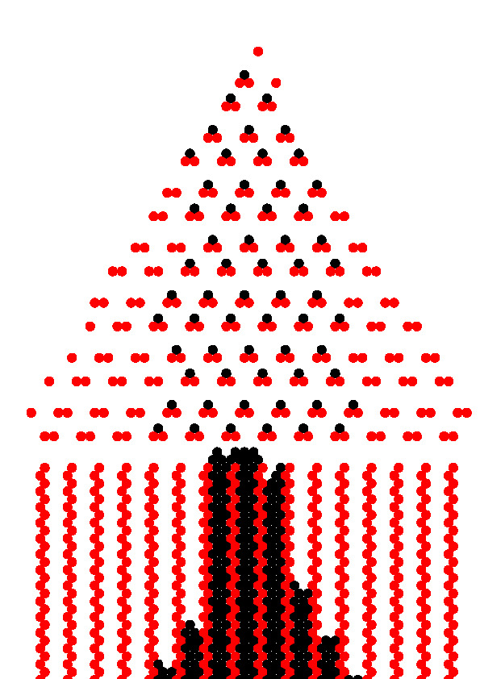

[figure not shown]

Mon code ment, mais à la fin, il raconte une histoire qui ressemble à la réalité.

C'est un métier où il est facile de douter de soi quand on fait des choses débiles à longueur de journée, c'est pour ça que le soir, il ne faut pas hésiter chez soi à préparer son établi, sortir l'éditeur, façonner du code, vérifier qu'il donne le résultat escompté, ranger son établis, terminer sa tâche et se sentir rassuré. Ou mieux, vider sa tête, ne penser à rien et éviter de surcharger son cerveau.

Devinez ce que j'ai fait pendant des années ?

Faire de ses petits doigts boudinés, quelque soit le métier, c'est un peu mentir. Le peintre en bâtiment donne l'illusion du marbre comme je donne l'illusion de la réalité, et la raison pour laquelle ça passe n'est pas un pouvoir magique lui sur la peinture moi sur le code, mais comment on rend un résultat qui paraît propre. (Tiens, va falloir que je recadre mon image).

Vous voyez le plus important pour moi quand je fais tomber des faux grains de sables n'est pas qu'ils respectent les lois de la physique dans leurs chutes, mais celle de la physique statistique à la fin. Et je trouve le tour de passe passe passant par tirer au hasard la déviation un mensonge particulièrement criant.

Néanmoins, à la fin de la simulation, les grains de sables virtuels sont bien tombés dans une enveloppe raisonnablement Gaussienne qui rappelle l'expérience homologue de la planche de Galton.

Quand tu vois que tes mensonges qui ne sont pas loin d'un délire psychotique sont capables de retranscrire la réalité, tu sais toujours pas si tu es fou, mais ça à l'air pas totalement fou du point de vue de la physique.

Et là, tu respires ... tu sais coder. Je ne suis peut être pas l'imposteur.

Mais une chose te tracasse : pourquoi cette impression de taquiner la folie quand on code ?

Après tout qu'est-ce qui distingue la psychose de la normalité ?

Le psychotique voit des choses, mais il sait pas que ce qu'il voit c'est faux.

Alors que le codeur, il voit des choses, mais il sait que c'est tellement vrai qu'il aura pas de bug ?

Les bugs mesurent la distance qui nous séparent de la folie. Plus notre distance mentale entre notre modèle et *le réel* est élevée plus le bug est critique. Et plus on est dans le déni, plus les bugs s'accumulent.

Pour certains jeux que j'ai vu passer, je qualifierais l'expérience de psychose professionnelle. Et pour la santé mentale des codeurs aspirés dans le tourbillon de marche de la mort (c'est comme ça qu'on appelle dans le métier les périodes de plusieurs semaines d'affilées (jusqu'à 50) pendant lesquelles les heures n'étant plus comptées : on respire son code, on mange son code, on rêve son code.

Et quand celui-ci est buguée, on ressent le traumatisme réel qu'il y a être dans une sorte de psychose logique, qui génère quand on est impliquée (et la boîte fait tout pour qu'on ne puisse pas de désimpliquer) des angoisses et malaises persistants. Surtout, que le piou piou qui code a rarement le contrôle sur les infras que les architectes astronautes du moment ont pondu.

PROUT la soute à charbon apporte son lot de stress mental, qui dans les cas les plus extrêmes nécessitent pour tenir des substances vénéneuses -parfois comme l'alcool- fournies en grande quantité de manière festive par l'employeur.

Je ne dis pas que j'accuse mes anciens employés de m'avoir poussé à l'alcoolisme : je dirais plutôt que j'accuse mes anciens employés d'avoir des rituels festifs qui n'aident pas quand on a des problèmes d'alcool auxquels on est plus prône du fait du métier. Je dis pas qu'ils sont genre des pyromanes qui balancent des allumettes enflammées sur tout ce qui bouge, je dis qu'ils laissent des flaques de pétrole partout, et que manque de bol, y'a eu une étincelle.

Par contraste, j'ai nettement préféré être déménageur : tu revenais crevé le soir, mais ton boulot ne venait pas polluer tes rêves. Tu pensais juste au jour d'hui et de demain. Au lieu d'avoir des pensées existentielles tu avais la légèreté d'expérimenter une vie simple et décontractante ... tant que tu regardais pas ton compte en banque à la fin du mois en retour d'expatriation avec toute ta vie à refaire.

En fait, c'est là où j'ai réalisé que mon attrait pour l'informatique est exagère et qu'en ceci, y'a bien quelque chose qui cloche. Malheureusement, la société n'aime pas trop laisser les citoyens changer de profession.

J'en suis même au point où je regarde la pratique même d'écrire sur un ordinateur un peu suspecte, me demandant si je ne suis pas en train de remplacer une expérience d'écriture que je trouve dérangeante par une autre qui pourrait l'être tout autant.

Mais je ne commettrais pas deux fois la même erreur : je vais apprendre à ne pas remettre l'ouvrage sur le métier le soir, mais plus tôt à respirer et m'aérer en profitant simplement de la vie, sans alcool.

## Ce que l'on fait pour pas rester scotché devant un écran

L'histoire de l'écran commence dans les années 80, quand la radio libre s'est tue, les routes sont devenues trop dangereuses pour faire du vélo, le temps déjà bien rempli par le sport toute la semaine, et qu'on veut se vider la tête le week end.

Alors, peut être que l'on va au stade, mais le stade est interdit aux gars qui viennent juste avec leur ballon jouer au foot alors qu'on est pendant les vacances et que la ville est déserte.

Peut être que l'on va à la gare, mais la friterie a fermé (car c'était au black), le dimanche c'est le jour du Seigneur et tout est fermé. On est en plein milieu des années SIDA et le moindre éduc spé qui file des capotes se retrouve inculpé pour attentat aux mœurs ...

Ça donne plus envie de sortir ... Il reste le bowling avec ses bornes d'acardes ou la campagne avec ses biniouzes accessibles et surtout le baby foot (babe) auquel on peut jouer tant que la maréchaussée contrôle pas (sinon, faut filer à l'anglaise par la porte de derrière et revenir payer plus tard).

Ça coûte les bornes d'arcade, et le flipper, alors on apprend à désosser un allume gaz pour court-circuiter le monnayeur et avoir des parties gratuites. Ou leurrer le monnayeur avec des pièces portugaises qui ont le poids et la taille des pièces de 10 Francs.

Et merde, si ça suffisait pas, l'alerte terroriste est levée au niveau le plus haut et ne va plus jamais quasiment la quitter après les attentats de St Michel.

Reste le bar, et s'arsouiller toute la journée comme les vieux qui rabâchent leurs gloires passées. Lol. Ça non.

Au final, un écran, ça coûte moins cher que de sortir. Partout il faut payer, et cher, ne serait-ce que pour se distraire. On a plus accès aux rivières pour se baigner, aux routes pour faire du vélos, aux stades pour taper le ballon. On a pas été attiré par les écrans : on a été poussé vers les écrans par un monde extérieur devenu hostile aux activités sociales de plein air comme le vélo, se baigner dans les endroits gratuits, pique-niquer, faire du sport, se déplacer proche de chez soi.

Se décrocher de l'écran, c'est détourner les yeux de l'ordinateur et retrouver l'intérêt dans des choses qui nous relient aux dimensions physiques et temporelles du commun.

Même si je dois prendre mon vélo et risquer ma vie pour aller chercher 1 kg de type 65, je vais expérimenter le pain rapide à 3 fermentations.

De l'eau, de la farine, de la levure : faire du pain est comme faire du code, une respiration pour confronter ce que l'on croit savoir, à ce que l'on arrive à faire. Sauf que cette fois, c'est la levure qui impose le temps de réalisation, pas moi. J'apprends à laisser le temps « lent » ré-envahir ma vie et lever le nez de mon écran.

## Ce qui nous ramène devant les écrans : l'épreuve de l'épreuve

L'aut' jour que je revenais d'un saut chez mon frangin ben magané, j'avais t'y pas une épreuve de cte bouquin justement. Que je corrigeais.

Et mes voisins ... du pub où je suis allé pour la première fois en des mois ... semblait intéressé par le livre (ils étaient bourrés aussi, ce qui les rendait plus accommodants aussi), et y'en a un qui pouvait pas lire à cause d'une déformation de la cornée. Ça m'a fait un peu chier car souffrant d'âge mes amis, et aussi de dyslexie, ça fait longtemps que je suis au courant du problème que je pouvais faire des efforts dès lors que je vais vers l'autre.

Alors, je suis reparti m'enfermer devant un écran, mettant toute tâche d'écriture en attente pour trouver comment dire à la chaîne d'outil de se démerder à changer cette putain de fonte à empattement difficilement lisible pour une fonte conçue par l'institut braille (Atkinson) afin d'être lisible.

Je respire, c'est fait. L'impression en informatique c'est peut être l'autre coin sombre en dehors de la soute à charbon où l'on a peur de se rendre.

Ce qu'il y a de marrant c'est que de derrière mes lunettes de vue de vieux à la myopie croissante je crois aider les autres, trolololololol.

Tout ça pour dire que dorénavant j'imprimerais mes épreuves en fontes lisibles par respect pour le hasard des rencontres et ceusses et celles qui auraient l'amabilité de me donner un retour sur des questions qui me taraudent.

## Les écrans ce mal qu'il faut éradiquer.

Car ... c'était mieux avant.

La litanie des choses nouvelles qui pervertissent la jeunesse devenue stupide est aussi vieille que Platon.

Platon qui blâmait la poésie et le théâtre de remuer les opinions des jeunes gens et prônaient la censure des messages qui auraient d'autres sens que le fait que la société va bien. Un Pompidou avant l'heure inventant l'ORTF avant qu'elle soit inventé. Ou un Pompidou inspiré par la cité idéale de Platon qu'on appelle République.

Dans ma jeunesse, avant que les ordinateurs s'imposent, ça a été le cinéma, la télévision, les ordinateurs personnels (non connectés), les mangas, le hard rock, le rap qui ont été accusé de pervertir la jeunesse.

J'ai trouvé dans les archives du début du XXé siècle des campagnes anti-livres pour dire si la panique morale sur la jeunesse qui change est nouvelle.

À chaque fois qu'on me dit « c'était mieux avant », je rétorque souvent : « les vieux nous cassent les burnes, faudrait les buter à la naissance ». L'âge vénérable utilisé pour asséner cet argument d'autorité apporte une touche d'ironie au message qui fait parti de la blague.

N'en déplaise à cette mode qui commence à faire de ma vie de vieux un espèce de jour sans fin grâce au retour infini de groupes de musique (merci aerosmith pour enfin prendre votre retraite), de marques de fringues, de chaussures, de vielles célébrités sur le retour : elle me fatigue.

La nostalgie à laquelle on expose les jeunes qui empêche de distinguer en sortant dans la rue à l'oreille et à l'œil d'un jour des années 90 est épuisant.

On croirait se réveiller tout les matins le même jour dans une société immobile qui a renoncé à changer. Tout les matins tu claques ton réveil, tu entends Nirvana, cheap trick, les rolling stones ... tu entends les mêmes débats et les mêmes conclusions.

Je ne sais pas si il est souhaitable que les jeunes changent et si l'exposition aux nouvelles technologies est bon ou mauvais, je dis que l'alternative : un monde qui se conserve du point d'un vieux comme moi ; **c'est chiant à mourir**.

Le besoin de changement social est un débat que je préfère trancher avec la question du confort intellectuel d'avoir son excitation quotidienne apportée malheureusement, et c'est pour ça que je me tourne vers le papier, une culture internet aujourd'hui en a fait un média de masse qui tend vers la stase intellectuelle.

Moi, j'aime mon quotidien comme un filtre ARMA : un filtre en traitement du signal qui mélange un peu de ce que l'on sait du passé avec ce que l'on anticipe du futur, et les partisans du tout progrès autant que du tout nostalgique me fatiguent ; je ne veux ni d'un monde bousculé tout les jours ni revivre le jour de la marmotte tout les jours j'aime ma vie comme un fleuve, dans lequel on ne se baigne jamais deux fois dans le même (sinon ça devient chiant).

Vu que la musique des années 90 revient en force, ça me rappelle nos discussions avec le doude sur la musique.

Dans ma jeunesse j'ai eu 2 amours : le punk, le metal et le funk. Et lui, c'était un fan de vieux rock bien saturés de funk moulés sous les aisselles à la george clinton and the parliament. Nos discussions musicales étaient intéressantes car quand on faisait une séance d'écoute musicale on échangeait.

Il m'apportait des morceaux du répertoire passé, j'apportais un répertoire plus récent et après on discutait des morceaux en discutant de ce qui nous plaisait ou moins. Ce qui nous permettait de bâtir une playlist confortable pour nous deux qui permettait de passer des bons moments.

Le doude m'a réconcilié avec une pratique de la musique qui m'avait rebutée (solfège, harmonie, répétition).

J'arrivais à déchiffrer des morceaux, voir à passer des trucs compliqués mais il y avait pas d'âme. C'était une routine.

Puis le doude, qui faisait de la guitare m'a redonné envie de faire de la musique comme si j'étais un débutant : j'ai acheté une basse et je m'y suis mis en autodidacte, oubliant même le solfège et appréciant les tablatures.

La basse est un instrument étrange pas vraiment mélodique (les fréquences basses ça bave faisant une bouillie infâme quand on joue deux notes trop proches) pas vraiment rythmique. Mais si il y a bien un endroit où la basse brille c'est le funk. Il suffit d'écouter Infectious Groove à l'époque où Roberto Trujillo en était le bassiste. Ce groupe a toujours été dans mon cœur comme la réunion de mes feux amours musicaux : le funk et le métal.

Et le doude a bien aimé. 15 ans plus tard, qu'ai je conservé de la pratique de la musique en solo ?

Et bien parfois, ça dé-stresse, parfois ça stresse, on le travaille, on arrête de le travailler, on fait des progrès, on régresse ...

Je dirais qu'on vu de l'investissement sur toutes ces années ça en vaut le coup, même si le résultat est pas de qualité a passé sur scène ou jouer pour des amis. Et parfois, je joue *amazing grace* en tentant de le passer en funk en pensant à lui.

## Bilan de 15 ans sans regarder la télé et moins internet.

J'ai ouvert un journal récemment alors que je suis en cure de désintox d'informations depuis 15 ans.

Il y a un moment, je me suis aperçu que ce truc m'excitait sur des sujets où je n'avais pas de contrôle. Ça vous donne une charge de stress inutile à penser aux choses de ce monde qui agissent sur nous sans que l'on puisse agir en retour.

Et, mon expérience perso sur le sujet, c'est que ça vous débarrasse d'angoisse existentielle insoignable. Je noterai comme positive l'impact de cette expérience sur ma vie de péquin.

En fait, tu ouvres un journal, c'est flippant : tout est vu au travers du prisme de grands Hommes avec des titres ronflants qui résolvent les problèmes du monde pendant que la masse impuissante subie.

Ils ont tellement du mal à trouver des pauvres que leur reportage sur la pauvreté en Haïti se fait par le truchement d'un prix Fémina (ou autre).

Vous allez me dire et les réseaux sociaux, mon bon monsieur, c'est bien pire.

Vu que je les ai quitté, il y a effectivement une notion de métrique de gloire qui fait que tout est aussi vu par le prisme d'«hommes célèbres» à ceci près que les gloires d'Internet se font sur des critères peut être aussi détestables que les critères anciens de la presse papier, mais ils ont l'intérêt d'être nouveau et de changer d'air un temps.

Mon avis sur les réseaux sociaux est le même que pour la presse : à consommer avec modération et ni l'usage immodéré ni l'abstinence dans ces domaines ne font de vous un in-fréquentable emmerdeur.

Mais, êtes vous sûr que la guerre à diable Vauvert est plus importante que de savoir si vous avez ce qu'y faut dans le frigo pour faire la popote du soir ?

# Les pages *Marie Claire*

Pendant mon service, et qu'on s'emmerdait (donc 80% du temps), pour attendre nous avions que 2 choses à faire fumer une bière et les lire les magazines féminins.

À l'époque j'étais encore accroc à la lecture, donc j'ai passé un an à lire du femme actuelle et j'y ai appris l'art délicieux des mots fléchés et autres.

Donc, là je fais ma pause :

## psychologie de bazar

Est-ce qu'écrire aide à guérir du passé ?

Hé bien non, on joue pas avec ses cicatrices en environnements toxiques quand elles sont purulentes.

Les traumas ont la gentillesse d'être « garbage collecté » par notre mécanisme de mémorisation, le soucis de nos mécanismes de guérison par effacement des mémoires associées, c'est qu'il en prend un paquet de bonnes avec lui.

Donc, si il est vrai qu'écrire peut aider à un travail de déminage autour de ses souvenirs pour tenter de voir où ça fait pas trop mal, et où on peut aller, alors, oui, c'est utile.

Le livre devient pour son auteur des balises indiquant des zones de déminages en cours avec un petit coin sécurisé d'où l'on peut commencer.

Un pas de travers et tu risques de te retrouver envoyé boulé comme quand tu mets les doigts dans la prise ... niveau « ah ! j'ai l'impression que les nazguls me voient …. »

Parfois, j'ai même suffisamment de recul pour trouver ça rigolo... mais pas à chaque fois.

Mais en échange, hey, ma récompense c'est de débloquer des mémoires du doude, son visage, ses cheveux mi longs de hippy, sa voix grave et son sourire généreux.

Donc, ouais, pt'et ben que la pratique d'un truc girly attrapé dans la lecture de la page psychologie de bazar *marie claire* ou *femme actuelle* a pu m'influencer.

Ben, mais si ça marche c'est pas stupide. Pas vrai ?

Allez, je vais me faire les ongles maintenant.

## Page bricolage : faîtes vos livres et colportez les !

Pas si vite : laissez moi d'abord pousser une gueulante contre l'informatique.

Si une chose est sûre, j'ai grandi dans un pays dont le taux de lettrisme dont numérique a explosé. Quoique les vieux cons disent sur avant c'était plus dur ... Maintenant, y'a bien la moitié de la population qui moufte quand on leur présente une division en pourcentage supérieure à 100.

Ça à l'air con, mais moi je trouve que c'est du lettrisme de math déjà pas mal.

La majeure partie de la population comprends les règles de trois quand on les égrène oralement et peuvent voir si il y a une erreur.

Je vais être honnête : ce que j'ai retenu de mes études de physiques appliquées c'est d'être un athlète de la règle de trois tant on découpe tout en série d'approximation linéaire. Je me sens plus musclé de la règle de trois, pas né avec un don inné de la règle de trois. Et c'est le hasard de ma naissance qui a gentiment prédestiné mais études supérieures étant fils de CSP+ moi même.

Il ne me semble pas que vous -*lecteurs à qui je destine ce pamphlet*- ne soyez bien représenté dans la production officielle de livre. La solution consiste donc à innover en appliquant des méthodes du passé qui ont marché à un problème nouveau.

Pour publier, en science comme en littérature, il faut à de rares exception près passer par des éditeurs patentés et une bureaucratie qui réussit l'exploit de vous faire payer pour vous donner un numéro unique de citation scientifique ou d'enregistrement d'un identifiant mondial unifié (ISBN).

Sérieux ?! J'ai pas passé ma jeunesse à faire des pochoirs dans les rues comme un bon keupon qu'écoutais starshooter et un peu les bérus (mais moins), pour me retrouver à pas proposer aut' chose.

### Colporter

À une époque où les médias était hyper contrôlés, bien plus que les routes, les marchands ambulants passaient pour des sommes modiques voire nulle des pamphlets aux origines incertaines (hollandaises et suisse). Pamphlets hostiles souvent aux classes sociales favorisées par la naissance, qui comble de culot, parfois écrites par un baron trafiquant d'arme ruiné qui prenait la défense du peuple.

Sans colporteurs, *le mariage de Figaro* dont le titre a inspiré un journal conservateur aux bottes de son propriétaire, n'aurait jamais existé.

Colporter, c'est discuter, lire, passer des pamphlets pseudonymisés que l'on apprécie dans la limite de son attention et de sa sensibilité et de la confiance que l'on a dans son auteur :D

### Écrire

[Le code source du livre est sur github,](https://github.com/jul/faire_un_livre) il vous donnera quand j'aura corrigé le site les indications sur comment faire ledit livre pour avoir le même rendu tout en tapant au kilomètre.

Si ça vous intéresse : mon éditeur de texte, c'est vi, et j'ai ajouté une sortie lisible.

Ensuite, écrire c'est comme marcher, tu fais une page après l'autre et t'oublies pas de respirer un bon coup dehors (>30 min) entre chaque pages.

Moi, j'ai un petit coté maso, je trouve ça drôle de trouver les souvenirs qui me fâchent et de sauter à pied joint dessus.

Je trouve drôle de rêver d'un monde où l'on me paierait pour coucher les textes des autres et en faire des cahiers de doléances que l'on colporterait et enverraient à nos représentants en toute occasion.

Où l'on se dirait : c'est bien présenté, c'est facile à faire, c'est rigolo et ça demande juste une bécane pourrie qui a latex, on a même une page web statique auto suffisante si on est amish de la techno (mais ils ont pas base64encodés les images pour en faire un html qui se suffit à lui même).

Malheureusement ce métier ne serait pas viable ...

J'imagine pas enquiller au SMIC 30h / pamphlet soit 300€ pour bien faire (correction et tout) ce qui me paraît loin d'être un métier qui me permettrait de voir plus d'écrivains populaires.

Par contre ... SI ... j'appelais ça *« conseil en écriture thérapeutique »* avec du publi-reportage dans *Marie Claire* ... peut être que j'aurais de quoi faire raquer 1000€/page m'enrichir et avoir suffisamment de temps libre aller écouter les histoires des squidjies du coin de la rue.

Ah ! *Femme actuelle*, un souvenir enfoui, de ce néant absolu que fût mon service militaire. Je me dis que si plus de monde l'avait fait, y'aurait moins de monde pour le fantasmer.

Ah ! J'ai des souvenirs enfouis traumatisants du service quand ils se sont jetés à 10 pour me raser les cheveux qui remonte.

Bon, je vous laisse, faut'qu'jaille me rouler en boule sur le canapé. Lol.

## Ce qui ne te tue pas te rendras plus fort (disent les idiots).

Mon cul, que c'est un ramassis de connerie ça ; chaque trucs s'accumulent et sont prêts à se réveiller en embuscade. Des fois tu revis même l'agression pendant que tu es en train de te faire défoncer en combat.

Et ... c'est perturbant ma foi. Je vivrais bien sans *moé* si on me demande.

Si je devais en tirer un proverbe inspirationnel ce serait

> Quand le chemin à travers les orties et les ronces, mène au même endroit que celui en gravier : soit pas con et marche sur le gravier.

> -- Comité de prévention des pratiques masochistes et auto mutilation.

# NSFW Le Vibe codeur repenti.

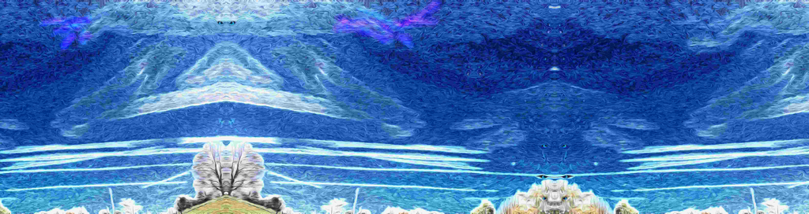

Illustration de tagada Johns WTFPL

Voilà, le sujet est peut être pas des plus drôles, et je vais parler drogue, code, (sexe) et rock n'roll.

Et je veux que les gens comprennent que ce qui suit n'est en rien une apologie des drogues, mais une condamnation des drogues.

Je vous renvoie à l'introduction de ce livre sur mon addiction personnelle qui a été dramatique pour un ami lui même addict et une perte de mon humanité, je tiens à être clair que je tente d'éclairer sur le fait que les addictions ne sont pas bonnes, et que le vibe coding avec ou sans IA est une addiction qui emprunte les mêmes ressorts.

## Ma légitimité de repenti

Avec le doude, comme dans cette industrie de la web agency de l'époque avec les autres potes ont pratiquait le vibe coding, pour tenir la charge.

J'ai acheté ma première barrette de shit à 35 ans, quand j'étais indé dans le domaine. Et c'était monnaie courante de voir passer de la coco, de la taz, des acides, de l'alcool, du chichon et de la beuh.

Sous prétexte de short list les boîtes d'apporteur d'affaire autour du domaine nous pressurait au jour de presta pour tenir des délais que des chefs de projets hallucinés sous on ne sait pas quoi avaient pondu comme pondable.

En fait, oui, mais genre pondable dans 4 à 6 fois l'enveloppe de temps impartie.

Et donc toi, tes semaines elles faisaient d'un coup 70h et les week ends une demi journée.

Fallait tenir. Je ne dirais pas non plus que dans le jeu vidéo ça prenait moins de drogue, on dira qu'en tout cas ça picolait largement plus. Il y a des drogues qui sont plus d'artistes comme dans le web, que des prolos du code comme l'alcool.

Oui, je me permets de faire un mépris de classe sur les drogues.

De même que je vais faire un mépris de classe entre vibe codeur sous IA et sous drogues qui vont dans la même direction, mais par des chemins différents.

Il y a une classe de drogue qui tue : l'héroïne. Les addictions pourrissent la vie, n'hésitez pas à vous faire aider, et à demander de l'aide.

Pendant ma sciatique, j'ai pu coder sous [influence](https://beauty-of-imagination.blogspot.com/2025/03/psycodelisme-coder-sous-lemprise-de.html). Il en reste pas grand chose si ce n'est ce borborygme final de l'opium en train de kicker sa descente.

Je peux vous dire que l'ai senti l'opium, j'avais littéralement le voile de la douleur avec une petite lumière qui ne venait QUE PARCE QUE JE PENSAIS À DU CODE. J'ai envie de parler de pratique thérapeutique du code.

C'est à ces épisodes sous stupéfiants parfois non choisis que je dois la satisfaction d'avoir une toolchain que j'utilise vim, ou linuxfr en markdown comme tribune que je lui dois d'avoir un sentiment de gratter l'encre numérique quand j'écris : mes outils me plaisent.

J'aime écrire au kilomètre dans vim en me concentrant sur Ce Que Tu Vois C'Est Ce Que Tu Signifies.

Mon plus grand kiffe aura été de faire mon premier livre papier au rendu pas dégueu avec la [reliure en carton maison](https://github.com/jul/faire_un_livre?tab=readme-ov-file#faire-un-livre-a5-avec-une-imprimante-recto-a4).

Il y a l'art et la manière, ce qui distingue l'artiste du prolo, le mec qui écrit un livre de celui qui écrit du code gratuit utile.

De même que je suis un addict repenti, je dois parler de ce qui attire l'addict ; le danger du vibe coding.

Une drogue et une IA ont en commun d'altérer les réponses normales que l'on aurait si on suivait nos réflexes avant. Dans un cas en changeant les circuits de rémunération du plaisir par titillement de capteur dans le cerveau, dans l'autre cas en utilisant le prompt pour dire ce qui plaît.

J'en veux pour preuve que j'ai pratiqué l'IA autant pour qu'elle me flatte dans le [sens du poil](https://beauty-of-imagination.blogspot.com/2024/11/entre-imitation-et-biais-systematiques.html), j'ai même [raconter le résultat cou ci couça de coder avec](https://beauty-of-imagination.blogspot.com/2024/10/is-chatgpt-good-at-generating-code-for.html).

Je pense avoir eu la révélation que je pouvais y faire appel, mais, qu'il fallait vachement se méfier du diable dans les détails (comme la fréquence de Nyquist) que l'IA ne voit pas forcément.

## Vibe code à 442Hz

La force d'une IA générative c'est d'être un bibliothécaire (pilleur) servile.

Tu demandes un truc un peu poussé ça te donne un exemple, pas exactement bien drette, mais suffisamment bon à l'emploi.

Si t'es pas trop regardant.

Quitte à toi de l'améliorer.

En audio, le truc auquel l'IA entrave rien c'est l'acoustique, il faut donc que tu repasses derrière elle pour être sûr que tu puisses accorder même ta corde la plus grave sans que l'erreur dépasse le signal.

Truc auquel l'IA quand elle te refile du code pour un accordeur de guitare ne pense pas.

## Vibe code sous opium

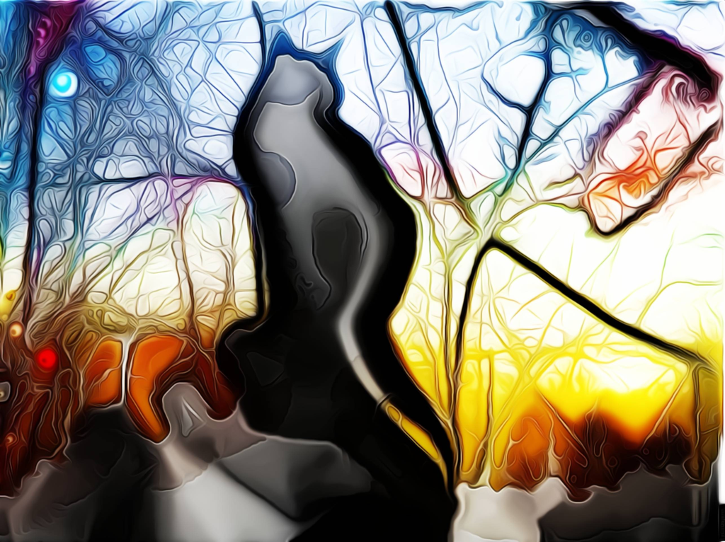

Illustration sous influence de tagada Johns WTFPL

C'est dans la doc de SCAM, ce code, à l'origine indirecte de mes livres car ça m'a donné un outil que j'aime manié, est fait en vibe coding aussi.

Tu réduis ton tunnel de concentration au minimum vital de ce que la douleur et les drogues te laissent, et pareillement tu obtiens une solution imparfaite.

T'as toujours un moment où ça s'arrête et tu vois le chantier qui avance de manière baroque et le code chaotique qui promet une maintenabilité douteuse.

## Vibe code sous THC

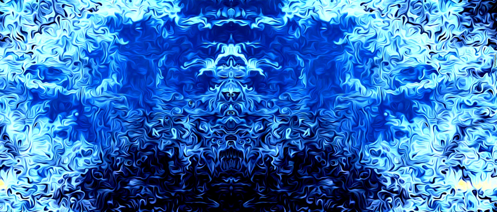

Illustration avec la permission de tagada Johns de code sous emprise

C'était avec le Doude, et j'étais déprimé par mon taffe parce qu'on faisait encore un site pourri en PHP mysql avec des problèmes d'encodage des accents.

Il m'a invité chez lui et j'ai fait ma première expérience de Vibe Coding

Shit, et bière.

J'étais en burnout, de plus en pouvoir de coder, et ce con m'invite une fois drogué, bourré en train d'écouter de la musique qui détend à nous concentrer sur un site web imaginaire qui ferait point de vente pour le resto du coin.

*On a vibe codé*, on était tellement pété que c'était une horreur pour sortir du code dans nos spécialités. Pour vous dire le HTML/CSS à la mode de l'époque c'était 0 table pour la mise en page, sinon t'es un noob.

Et bien nous en tant que vibe codeur on a pris plaisir à utiliser des tables car les tables, c'est rudement pratique pour représenter une table ... comme celle d'un menu de restaurant.

On avait un zoli panier dans la single page app avant que ce soit à la mode où le panier était dans le dom.

Y'avait du drag'n drop et ... on a pris une demi journée.

Ok le code était inmaintenable, fait sous l'effet de drogues et biscornu, mais j'ai eu besoin de ce moment de retrouver confiance en moi et dans mes compétences.

Et le dood l'a bien compris et il a été le premier ami avec lequel j'ai découvert la complicité en codant.

Depuis, il y a en a eu d'autre, mais lui m'a fait redécouvrir le plaisir de coder.

Comment dire du mal de la drogue comme de la musique alors que j'ai en tête en pensant à cet épisode au morceau *last night the DJ saved my file*.

Et docteur *feelgood* celui qui vous fait vous sentir bien quand votre corps est perclus de douleur.

On pense aux drogues pyschotropes pour la récréation, mais, mes cocos, ont vieilli, on a pas forcément eu des supers postures aux bureaux, donc passer un certain âge c'est opium pour la sciatique. Et croyez moi quand vous allez manger votre sciatique vous allez moins faire les fiers qui supportent la douleur stoïquement.

## Vibe coder sous alcools (et sexe)

[figure not shown]

Illustration sous influence de tagada Johns WTFPL

Je crois que ça a été mon premier logiciel libre, et je ne devrais pas en être fier : freshmeat ; le robot pour baiser.

Là encore la vibe de l'alcool est pas la même que l'IA, l'opium où le THC : on a les doigts baveux.

On fait plus d'erreurs de frappes par exemple. C'est pas hyper pratique ça pousse à utiliser des noms de variables plus court. Pour la lisibilité après coup, on repassera.

Dire que j'étais un gros con limite limite ne serait pas exagéré.

Moi et mon foutu complexe d'infériorité de quasi puceau qui aimerait rattrapé le temps perdu et qui traîne avec ses amis toxiques autour d'une bière :

> « **et il faudrait un robot pour draguer à ma place sur meetic !** »

Ayant traîné mes guêtres dans des bars avec que des geeks comme moi pour la drague c'était pas top. Mais par contre qu'est-ce qu'on était bon à trouver des théories foireuses quasi incels pour justifier le fait que l'on faisait chou blanc.

J'étais par ailleurs pour tenir les cadences du taffes avec ses cadences, missions implosives (burnin), inter contrat avec décompression explosive en mode décompression alcoolisée explosive.

Et à l'époque j'avais aucun logiciel sortie d'une page web libre qui existait.

J'étais dans le logiciel libre et je rêvais d'exister avec quelque chose qui ferait que j'aurais mon quart d'heure de gloire.

Et au lieu de visiter l'utilité je décider de réussir à coucher grâce à mon code : moi le sous doué de la communication non verbale en distillant ma compréhension de l'humain en un minimum de code.

La revanche du geek sur la belle.

Ou au lieu de montrer mon code, je monterais par ma vie pleines de partenaires et de folies que mon code libre est cool.

*rock'n roll*.

Et bien, c'est sous alcool qu'une nuit après avoir ouvert un compte par femme je me suis posé la question de comment minimiser l'interaction et maximiser le retour à partir d'interaction sur une page web.

Sur meetic on était averti quand quelqu'un passait, une sonnette à stalker valorisée.

J'ai juste fait un bot qui passait sur les pages sans interagir en ajoutant une base de données pour me permettre de viser en masse à l'échelle d'un code postal avec juste une légère interaction.

Ce bot a marché du feu de Dieu, j'enquillais les portes de « bonjour, comment vas tu ? » bien plus vite que quand j'avais fait les premiers tests humains pour tester la preuve de concept.

Et c'est un point important du vibe coding quelque soit la substance : ne jamais perdre de vue une métrique simple de « j'ai ce que je veux » quand on plonge dans du vibe coding, sinon on arrive nul part.

En vibe coding, vos ressources en complexité sont limitées.

J'ai toujours raconté cette histoire à mon premier rendez vous par mauvaise conscience de les avoir manipuler. Le fait que je le raconte a toujours fait rire, et a impressionné certaines que je ne regrette pas d'avoir rencontrées.

Mais, maintenant, je suis marié, repenti des conneries, que j'ai quitté comme Ulysse quitta Nausicaa pour les bras de Pénélope, en la bénissant et non la maudissant.

Et dans un petit cercle de codeur libre, il y avait une légende urbaine d'un mec (un peu limite limite gros con) qui baisait à couilles rabattues grace à l'informatique.

## Vice coding avec et sans drogues

Depuis, j'ai appris le vibe coding sans drogues (parfois avec).

Mais en fait, sans drogue c'est plus drôle.

En général, ce sont [mes gists](https://gist.github.com/jul).

Comme vous le constaterez pas mal de mes projets commencent sous la forme d'un *gist*, un petit morceau de code de moins de 500 lignes le plus compact possible.

Comme [celui-ci](https://gist.github.com/jul/b89a672abf1df9a6783e65977de7d74c) concernant bluesky qui va préfigurer le [trollomètre](https://github.com/jul/trollometre/).

Beaucoup reste comme du code kleenex dans l'histoire des poubelles de la mise en commun.

À chaque fois, je pars d'une idée qui est drôle et qui *à terme* titille mes sens, les yeux, les oreilles ... et j'aime que mon code produite une vibration.

Comme mon accordeur de guitare.

Le Vibe coding c'est ce qui me fait me sentir bien en temps que codeur.

Par contre, quand il est sous influence que ce soit de drogues ou de l'IA, j'enjoins mes frères et mes sœurs à faire attention aux phénomènes addictions et leurs effets qu'ils entraînent.

Autant les pertes de repères pour les drogues sont documentées, autant celles pour l'IA ne le sont pas.

# Qu'est ce que le vibe coding ?

Finalement, il faut bien définir *vibe coding*. Et, je vais m'essayer à une définition simple :

> On vibe code quand on est pas dans l'écriture de code chiante sans vibration propre à l'écriture de code de prod. Celui qu'on pose sur github.

Alors évidemment, j'ai posé sur gihtub du [code vibe-codé](http://github.com/jul/SCAM), ce qui affaiblit mon propos. Mais, j'ai aussi posé du code que j'appellerais sans vibrations comme yahi ou archery qui ont en commun d'être PEP8, d'avoir un commit par modif, un changelog, s'appuyant sur le manuel python (du fait des faibles dépendances).

Un code sans *« vibe »*, c'est ce que dans le métier on appellerais du code propre fait dans des conditions propres en partant d'un ticket qui rappelle le besoin fonctionnel.

## Le vibe coding est-il utile ?

Ma production de code est séparé en deux en ce que je juge digne de github (ou n'importe quel autre gestionnaire de version) et ce qui tient en un simple fichier (un gist).

Je qualifierais ma production de gist de *« vibe coding »*. Du code fait sous influences parfois de produits stupéfiants, parfois pas qui subit dans son processus une influence disruptive que ce soit dans le comment (pas de PEP8, pas de ticket, ...) la manière, ou l'esprit (suivre une IA, un post de blog, une idée à la con).

Perso ce code m'est utile comme fondation pour mes projets. Assez souvent, je pars d'un gist vibe codé avant de le jeter (ou pas) pour en faire la base d'un code propre.

Il est la Preuve de Concept, le prototype avec lequel j'aime bien démarrer du code ennuyeux.

Il permet assez souvent soit de tester les limites d'une idée rapidement, soit au contraire, de valider sa pertinence en élaguant à l'extrême le besoin de rigueur propre à *tout faire from scratch*.

## Fausse repentance du vide coding ?

Suis je en train d'admettre que je suis pétri de contradictions ? Oui, mais aussi que mon rejet de ce qu'on appelle *vibe coding* le codage assisté par IA n'est en soit ni disruptif, ni souhaitable.

Le vibe coding que je pratique inclus l'IA, mais je n'en suis pas satisfait.

La qualité du code produit en regard de ce qui importe le plus pour moi qui est : un résultat qui passe le feu de la validation d'une idée ne marche pas.

L'IA est par trop approximative et son code blindé de malfaçon qui le rende inutilisable sans une plongée dans le code pondu qui est hyper-verbeux qui est plus une perte de temps et de maintenabilité inacceptable que ses alternatives.

Au moins quand je code bourré ou sous influence du shit, mon code déviant reste focalisé à sa manière biscornue sur l'objectif, et c'est là où l'art du vibe coding brille en sachant passer les barrières de l'altération de conscience pour rester en synchronicité avec l'idée de départ.

Contrairement à une croyance populaire, faire n'importe quoi qui marche demande de la discipline intellectuelle.

## Le libre au delà du logiciel

Quand je fume du shit, mes circuits de dopamines se remettent d'équerre, et au lieu d'avoir mon état d'esprit de codeur marqué par des tsunamis de burnout déprimant, je retrouve de la gaieté, de la joie et de l'optimisme.

La *vibe* qui me plaît le plus quand je code, c'est retrouver le plaisir d'un enfant à jouer.

Dans un univers professionnel qui me remise de part mon âge au cliché du vieux qui n'est plus à jour, je peux évoluer, me maintenir à jour, tester me sentir vivre.

Mon *vibe coding* se différencie de celui par IA, qu'il s'intéresse au code comme vibration dans nos vies. Certes, être enfermé en tant que personne dans un Beruf (vocation) a le goût et l'odeur de l'aliénation productiviste qui fait oublier femme et enfants, mais il est aussi ce qui fait que l'on peut ne pas se définir par sa norme sociale de codeur périmé par l'obsolescence supposée liée à l'âge.

Mon *vibe coding* c'est celui qui mêle mon récit personnel à celui de mon code, liant mon hobby d'écrivain libre auto-décrété avec celui de codeur. C'est pour ça que j'ai mis dans le [manuel de SCAM](https://raw.githubusercontent.com/jul/scam/refs/heads/main/assets/aide.book.pdf), le récit sa genèse sous opium et douleur. Pour casser le mur entre l'outil libre et la subjectivité de l'auteur. Pour remettre l'humain dans le récit informatique.

Les hommes et femmes qui font les logiciels sont aussi importants que le logiciel fait, et pour qu'il soit libre, je trouve important qu'il libère aussi l'homme et la femme qui en ont de l'impératif utilitariste ou maniériste.

Nous devons en plus de veiller à ne pas faire de bugs, à entretenir notre joie de coder sans attente d'un quelconque bénéfice, et cela ne peut se faire en se soumettant exclusivement à une éthique de « la bonne manière de faire ».

Enfermer dans *la bonne manière de faire*, notre code est certes maintenable, facile à modifier, à étudier, étendre, corriger, mais il ne faut pas que ce soit au détriment de notre plaisir.

Il est important dans un monde normatif socialement et techniquement de savoir dé-normaliser par morceau notre manière de coder en choisissant les influences bonnes ou mauvaises (comme l'IA) qui nous permettent d'atteindre la joie.

Et l'IA ne m'a pas donné de joie dans mon code, que des mots de crâne à réviser les bases de l'acoustique.

# Le besoin de vibration

A bien y penser, que l'on code ou que l'on écrive un livre, on a besoin de vibration, de petit retour de forces qui nous disent si on peut être heureux de son logiciel.

Certains *une version de moi passée par exemple* ont des attentes en terme de retour de force, de retour sur investissement qui dépassent ce que l'on peut obtenir.

En faisant du code par exemple, les attentes que l'on peut avoir c'est :

- du succès qui se mesure en audience web, pouce bleus de réseaux sociaux ;
- la capacité de vivre économiquement de par son logiciel libre de son activité de codeur ;
- d'être invité à des confs pour exposer à quel point on est brillant ;
- d'avoir des commentaires positifs sur IRC ou des coins de moules comme linuxfr ;
- d'avoir un logiciel qui marche et remplis un besoin ;
- des téléchargements du dit logiciel ;
- d'avoir tous ses badges de CI/CD/code coverage en vert ;
- d'avoir tous ses tests aux verts ...

Ça peut être un ou plusieurs de tout ça, l'attente peut être démesurée ou mal placée ... par exemple à quoi cela sert-il d'avoir tout ses tests et badge en vert quand à la fin on a ni librairie, ni logiciel qui soient téléchargés, et que soit même on utilise pas le logiciel et qu'on s'ennuie comme un rat mort à écrire le code ?

Néanmoins à l'inverse de l'écriture, nos chaînes de production sont pleines de « vibrations » de retour de force.

Comme par exemple nos files de tickets (issues en français de Paris) nous indiquent quand elles s'ouvrent qu'on a des utilisateur en retour.

La motivation s'entretient.

Celui qui code seul dans le désert sans attentes, et l'attente minimale du logiciel libre par rapport à son code, pour lequel on choisit une licence ... *libre*, c'est avant tout qu'il soit partagé, qu'il serve à plus que soi.

Ça paraît évident, et je me méfie de l'évidence, il n'y a rien de mal à coder pour soi et partager son code. C'est une motivation tout à fait légitime.

Si on en tire du plaisir. Cependant, avec la [divulgation de ce chapitre sur linuxfr](https://linuxfr.org/users/jul/journaux/vibe-coding-sous-toutes-ses-formes-un-nouveau-chapitre-de-sherpa-du-code) je m'aperçois que l'exercice pour la beauté du geste ne me satisfait pas.

Et que l'absence de retour, ne me satisfait pas.

Peut être que le sujet était trop lourd pour se cramer sur des forums publics ? Alors j'ai été sur IRC, les réseaux sociaux, faire une partie que je déteste des activités libre qui est [l'évangélisation](https://jul.github.io/cv/yahi.html#prendre-sa-casquette-de-repr%C3%A9sentant).

J'ai écumé IRC, bluesky facebook en espérant un retour, et au coin les plus paumés d'internet j'ai eu des réactions :

Raph m'a dit :

> Faire du logiciel libre, ces comme faire une bonne action : ne le fais pas en espérant en tirer des bénéfices, sinon tu seras déçu. Fais-le parce que tu veux/dois le faire. La reconnaissance et la rémunération éventuelles seront un bonus, mais il ne faut pas que ce soit le motif.

Mais je ne suis pas d'accord avec cette vision d'ermite.

Et j'ai aimer voir jaillir d'un coin d'internet LA réaction humaine sur mon chapitre présent qui était :

> je me reconnais dans tes écrits, j'étendrai ma lecture quand j'aurai un moment. Mais ça fait plaisir, me sens moins seul ^^

Rencontrer une communauté est le plus agréable des plaisirs. Et je crois que c'est ce qui disqualifie l'IA au second ordre.

## Riquet la Houppe

L'[histoire de Riquet la Houppe](https://touslescontes.com/biblio/conte.php?iDconte=170) est un conte de Perrault nous contant l'histoire d'un fils né si laid qu'on lui donne le super pouvoir de pouvoir s'attribuer les mérites intellectuels des autres en ne faisant quasi rien.

C'est littéralement un utilisateur d'IA.

Je vous passe le conte dont la morale valorise les utilisateurs d'IA dans le sens où ce conte est une pirouette où tout ce qui est vanité, beauté, faux semblants sociaux priment sur la sincérité grace au deus ex machina du pouvoir de l'amour et vous donne la mienne : à la fin de l'histoire Riquet s'est nullement débarrassé de son défaut de s'attribuer les mérites des autres pour paraître intelligent et reste coupé à vie de la communauté qu'il pille. Certes il a réussi à trouver vagin à son pied, ce qui semblait son seul objectif, mais il failli définitivement à s'amender, se réformer pour s'intégrer.

Il en est ainsi des utilisateurs d'IA qui ont la vibration d'un retour de force positif social au détriment de l'intérêt commun en pillant les données des autres. Mais au sein de la communauté qu'ils pillent sont ils bien vu ?

C'est un superbe conte sur ce qu'est la Gloire que l'on recherche et comment certains ne visent pas la recherche pour le plaisir mais pour la *fame*, être fameux et sont prêts à prendre tous les raccourcis.

## L'anti Riquet à la Houppe

Je suis et ne suis pas Riquet. Certes, je prends du code aux autres (libres), mais je le cite, je m'appuie dessus.

Certes, je recherche quelque chose de social, de la reconnaissance mais je ne cherche pas à m'attribuer le mérite du code des autres.

J'ai aussi, mis la pédale douce sur mes vanités de control freaks.

Si vous lisez la version HTML authentique de ce livre, vous pouvez appuyer sur F12 et constater dans la console du développeur qu'il n'y a nul traceur, nulle sonde pour savoir qui lit, pas de pixel caché, juste un appel pour charger les fontes.

Les logiciels libres que je publie ont aux mieux celles de [pypi stat](https://pypistats.org/packages/yahi) mais sinon, celles très rudimentaires de github.

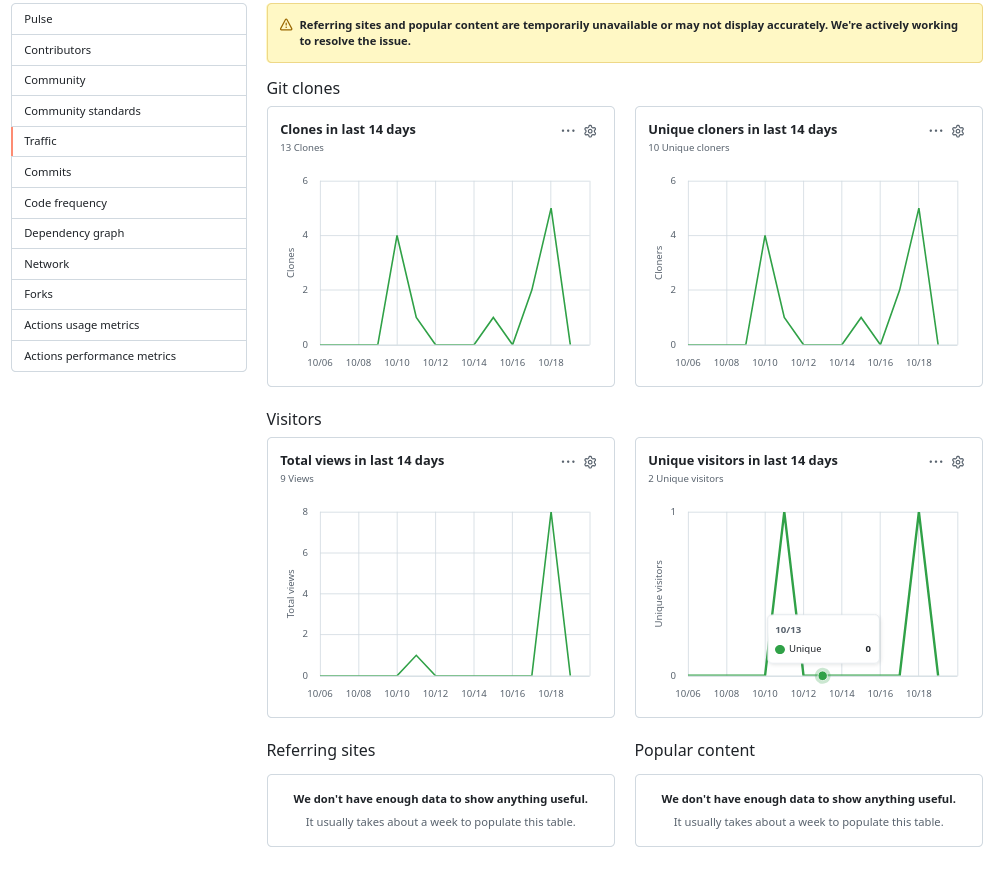

stats de github

Autrement dit bien qu'ayant eu comme domaine professionnel le traçage des utilisateurs (j'ai travaillé dans la pub web) et donc le savoir faire pour cela, j'ai choisi de ne rien savoir de mes lecteurs qui lisent le livre en version HTML.

0 journaux web que je peux exploiter avec *yahi*, pas de traceur javascript, pas de connaissance des « référents » à l'URL du livre, pas d'historique des chargements.

Comme je suis en « autoédition numérique », j'ai mis nul part ailleurs que sur mes githubs les livres sans qu'il y ait de maison d'édition pour en faire la promotion ou de site communautaire avec des forums.

J'ai fini par m'installer sur les dépêches de linuxfr pour promouvoir les livres et mes logiciels à mon plus grand bonheur.

Et parler avec ne serait-ce que deux humains de ces projets, ça change de la communauté sociale de tous les jours qui nous défini par un statut social de chômeur mal rasé handicapé par une douzaine de burnout mal digérés dont les autres parents prestigieux refuse d'inviter ma fille à leur anniversaire pour pas que la pauvreté les contaminent.

D'un seul coup, je suis pour ce que je crée et non ce que je reflète.

Mêmes limitées (je ne suis pas le khador de la tribune linuxfr) ce peu d'interactions me fait du bien.

Ma conclusion sur le *vibe coding* est sans appel : *il n'y a pas de vibe (coding|writing) par IA qui tienne, la seule vibe qui compte c'est de sentir dans une communauté et l'IA n'est pas un humain.*

# Liste des liens

**https://www.syntec.fr/convention-collective/**

La convention collective SYNTEC

**https://agilemanifesto.org/**

« l'agile manifesto »

**https://github.com/jul/faire_un_livre**

Le code source du livre est sur github,

**https://beauty-of-imagination.blogspot.com/2025/03/psycodelisme-coder-sous-lemprise-de.html**

influence

**https://github.com/jul/faire_un_livre?tab=readme-ov-file#faire-un-livre-a5-avec-une-imprimante-recto-a4**

reliure en carton maison

**https://beauty-of-imagination.blogspot.com/2024/11/entre-imitation-et-biais-systematiques.html**

sens du poil

**https://beauty-of-imagination.blogspot.com/2024/10/is-chatgpt-good-at-generating-code-for.html**

raconter le résultat cou ci couça de coder avec

**https://gist.github.com/jul**

mes gists

**https://gist.github.com/jul/b89a672abf1df9a6783e65977de7d74c**

celui-ci

**https://github.com/jul/trollometre/**

trollomètre

**http://github.com/jul/SCAM**

code vibe-codé

**https://github.com/jul/yahi**

yahi

**https://github.com/jul/archery**

archery

**https://raw.githubusercontent.com/jul/scam/refs/heads/main/assets/aide.book.pdf**

manuel de SCAM

**https://linuxfr.org/users/jul/journaux/vibe-coding-sous-toutes-ses-formes-un-nouveau-chapitre-de-sherpa-du-code**

divulgation de ce chapitre sur linuxfr

**https://jul.github.io/cv/yahi.html#prendre-sa-casquette-de-repr%C3%A9sentant**

l'évangélisation

**https://touslescontes.com/biblio/conte.php?iDconte=170**

histoire de Riquet la Houppe

**https://pypistats.org/packages/yahi**

pypi stat

**https://actu.fr/ile-de-france/pontoise_95500/pontoise-la-statue-contestee-du-general-leclerc-c-est-toute-une-histoire_57570214.html**

j'ai repeint les couilles de ce fils de sa race d'enfant du pays criminel de guerre et beau frère d'un tyran